# loan_01-Copy2

## kaggle : All Lending Club loan data

LendingClub: 도시 고객들에게 다양한 유형의 대출을 전문적으로 제공하는 회사

- 은행 및 금융 서비스 분야의 위험 분석(Risk Analytics)
- 고객에게 대출금을 빌려주는 동안 손실 위험을 최소화하는 데 데이터를 어떻게 사용할지가 중점

회사가 대출 신청을 받으면, 신청자의 프로필을 기반으로 대출 승인 여부를 결정

- 만약 신청자가 대출금을 상환할 가능성이 높다면, 대출을 승인하지 않는 것은 회사에 사업 기회 손실을 가져옴
- 만약 신청자가 대출금을 상환할 가능성이 낮다면(즉, 채무 불이행(부도) 가능성이 높다면), 대출을 승인하는 것은 회사에 재정적 손실을 초래 가능

데이터

- 과거 대출 신청자들에 대한 정보와 그들이 '채무 불이행(부도)'을 했는지 여부
- 목표: 어떤 사람이 채무 불이행할 가능성이 있는지를 나타내는 패턴을 식별하는 것
- -> 패턴을 활용: 대출 거부, 대출 금액 축소, (위험한 신청자에게) 더 높은 이자율로 대출해 주는 등의 조치 취함 등

개인이 대출을 신청할 때, 회사가 취할 수 있는 결정

1. 대출 승인 (Loan accepted) : 아래 3가지 시나리오 가능
- 완전히 상환됨 (Fully Paid): 신청자가 대출금(원금 및 이자)을 전액 상환
- 현재 상환 중 (Current): 신청자가 현재 할부금을 납부하고 있는 중이며, 대출 기간이 아직 끝나지 않음. 이들은 '채무 불이행자'로 분류되지 않음.
- 대손 처리됨 (Charged-off): 신청자가 장기간 제때 할부금을 납부하지 않아 채무 불이행(부도) 상태가 됨
2. 대출 거부 (Loan rejected)
- 회사가 대출을 거부한 경우(예: 신청자가 요구 사항을 충족하지 못함 등)
- 대출이 거부되었기 때문에 해당 신청자들과의 거래 내역이 회사에는 없으므로, 이 데이터는 회사에(그리고 이 데이터셋에도) 포함되어 있지 않음

🎯 비즈니스 목표 (Business Objectives)

- LendingClub은 개인 대출, 사업 대출, 의료 시술 자금 조달 등을 용이하게 하는 가장 큰 온라인 대출 시장입니다. 대출자들은 빠르고 간편한 온라인 인터페이스를 통해 더 낮은 이자율의 대출에 쉽게 접근할 수 있습니다.
- 대부분의 다른 대출 회사들과 마찬가지로, '위험한' 신청자들에게 대출을 제공하는 것이 가장 큰 재정적 손실(신용 손실)의 원인입니다. 신용 손실은 대출자가 빚진 돈을 갚기를 거부하거나 돈을 들고 도주했을 때 대출 기관이 잃는 돈의 양을 의미합니다. 다시 말해, 채무 불이행을 하는 대출자들이 대출 기관에게 가장 큰 손실을 입힙니다. 이 사례에서는 '대손 처리됨(charged-off)'으로 분류된 고객들이 '채무 불이행자(defaulters)'입니다.
- 만약 이러한 위험한 대출 신청자들을 식별할 수 있다면, 그러한 대출을 줄여 신용 손실액을 줄일 수 있습니다. EDA와 머신러닝을 사용하여 이러한 신청자들을 식별하는 것이 이 사례 연구의 목표입니다.
- 즉, 회사는 대출 채무 불이행의 주요 원인(또는 주요 변수)을 이해하고자 합니다. 이는 채무 불이행의 강력한 지표가 되는 변수들을 파악하는 것입니다. 회사는 이 지식을 대출 포트폴리오 및 위험 평가에 활용할 수 있습니다.

```python
# import pandas as pd

# data = pd.read_csv('accepted_2007_to_2018Q4.csv', parse_dates=['issue_d'], date_format='%b-%y', low_memory=False)
# df_c = data.copy()

# data.head()
```

```python
# data.info()
```

```python
# # 각 컬럼의 정보 추출
# column_names = data.columns.tolist()  # 컬럼명 리스트
# non_null_counts = data.count()        # 각 컬럼의 비결측 데이터 개수 (Series 형태)
# data_types = data.dtypes              # 각 컬럼의 데이터 타입 (Series 형태)

# # 정보를 DataFrame으로 결합하여 보기 좋게 출력
# column_info = pd.DataFrame({
#     '컬럼명': column_names,
#     '데이터 개수 (결측치 제외)': [non_null_counts[col] for col in column_names], # Series에서 값을 가져옴
#     '데이터 타입': [data_types[col] for col in column_names] # Series에서 값을 가져옴
# })

# # 이 정보를 CSV 파일로 저장
# # index=False는 DataFrame의 인덱스를 CSV 파일에 저장하지 않도록 합니다.
# c#olumn_info.to_csv('column_information.csv', index=False, encoding='utf-8-sig')

# #print("컬럼 정보가 'column_information.csv' 파일로 저장되었습니다.")
```

```python
# import pandas as pd

# missing_values = data.isna().sum()

# missing_values_df = missing_values.reset_index()
# missing_values_df.columns = ['컬럼명', '결측치 개수']

# #missing_values_df.to_csv('missing_values.csv', index=False, encoding='utf-8-sig')

# #print("각 컬럼의 결측치 개수가 'missing_values.csv' 파일로 저장되었습니다.")
```

## 대조용 원본 데이터 따로 생성

최소한의 전처리만 수행

- 문자형 컬럼들 (object) → 숫자형으로 변환 (Label Encoding)
- 결측치 → 간단한 방식으로 대체 (예: fillna)
- 불필요한 컬럼 (예: id, member_id) 제거

```python
# import pandas as pd
# from sklearn.preprocessing import LabelEncoder

# # 1. ID 컬럼 등 제거 (모델에 의미 없는 열 제거)
# df_c = df_c.drop(['id', 'member_id'], axis=1, errors='ignore')

# # 2. 문자열(object) 컬럼만 추출
# obj_cols = df_c.select_dtypes(include='object').columns

# # 3. 각 문자열 컬럼에 대해 Label Encoding (단순하게)
# for col in obj_cols:
#     df_c[col] = df_c[col].fillna('Missing')  # 결측값을 'Missing'이라는 문자열로 처리
#     le = LabelEncoder()
#     df_c[col] = le.fit_transform(df_c[col])

# # 4. 수치형 결측값은 0으로 대체 (또는 평균, 중간값도 가능)
# df_c = df_c.fillna(0)
```

```python
# df_c.to_csv("lendingclub_minimal_preprocessed.csv", index=False, encoding='utf-8')
```

```python
import pandas as pd

df_c = pd.read_csv("lendingclub_minimal_preprocessed.csv", encoding='utf-8')
df_c.head()
```

|  | loan_amnt | funded_amnt | funded_amnt_inv | term | int_rate | installment | grade | sub_grade | emp_title | emp_length | ... | hardship_payoff_balance_amount | hardship_last_payment_amount | disbursement_method | debt_settlement_flag | debt_settlement_flag_date | settlement_status | settlement_date | settlement_amount | settlement_percentage | settlement_term |
| --- | --- | --- | --- | --- | --- | --- | --- | --- | --- | --- | --- | --- | --- | --- | --- | --- | --- | --- | --- | --- | --- |
| 0 | 3600.0 | 3600.0 | 3600.0 | 0 | 13.99 | 123.03 | 2 | 13 | 479209 | 1 | ... | 0.0 | 0.0 | 0 | 1 | 60 | 3 | 68 | 0.0 | 0.0 | 0.0 |
| 1 | 24700.0 | 24700.0 | 24700.0 | 0 | 11.99 | 820.28 | 2 | 10 | 141409 | 1 | ... | 0.0 | 0.0 | 0 | 1 | 60 | 3 | 68 | 0.0 | 0.0 | 0.0 |
| 2 | 20000.0 | 20000.0 | 20000.0 | 1 | 10.78 | 432.66 | 1 | 8 | 508568 | 1 | ... | 0.0 | 0.0 | 0 | 1 | 60 | 3 | 68 | 0.0 | 0.0 | 0.0 |
| 3 | 35000.0 | 35000.0 | 35000.0 | 1 | 14.85 | 829.90 | 2 | 14 | 199294 | 1 | ... | 0.0 | 0.0 | 0 | 1 | 60 | 3 | 68 | 0.0 | 0.0 | 0.0 |
| 4 | 10400.0 | 10400.0 | 10400.0 | 1 | 22.45 | 289.91 | 5 | 25 | 91957 | 3 | ... | 0.0 | 0.0 | 0 | 1 | 60 | 3 | 68 | 0.0 | 0.0 | 0.0 |

5 rows × 149 columns

```python
df_c.info()
```

```
<class 'pandas.core.frame.DataFrame'>
RangeIndex: 2260701 entries, 0 to 2260700
Columns: 149 entries, loan_amnt to settlement_term
dtypes: float64(112), int64(37)
memory usage: 2.5 GB
```

## target : loan_status (대출 상태)

```python
# data['loan_status'].value_counts(dropna=False)
```

## 2. `loan_status` 값 분포 확인

`loans['loan_status'].value_counts(dropna=False)`를 실행하면 `loan_status` 변수에 어떤 값들이 얼마나 존재하는지 확인할 수 있습니다.

| 상태값 | 설명 |
| --- | --- |
| Current | 현재 정상적으로 상환 중인 대출 |
| Fully Paid | 전액 상환 완료 |
| Charged Off | 상각 처리(사실상 부도) |
| Late (31-120 days) | 31~120일 연체 |
| In Grace Period | 유예 기간 |
| Late (16-30 days) | 16~30일 연체 |
| Does not meet the credit policy. Status:Fully Paid | 신용 정책 미충족이지만 상환 완료 |
| Does not meet the credit policy. Status:Charged Off | 신용 정책 미충족 및 상각 처리 |
| Default | 부도 상태 |
| NaN | 상태 정보 누락 |

## 3. 분석 대상 데이터 선정

이 분석에서는 다음 두 가지 상태의 대출만 사용합니다:

- `Fully Paid` (완전 상환)
- `Charged Off` (상각 처리)

**선택 이유:**

- 분석 목적은 대출이 "성공적으로 상환되었는지" 또는 "부실화되었는지" 구분하는 모델을 만드는 것.
- `Current` 등 아직 결과가 정해지지 않았거나, 불확실한 상태는 모델 학습에 부적절함.
- 기타 상태 (`Late`, `Default`, `In Grace Period`, `Does not meet credit policy`, `NaN`)는 분석 목적과 부합하지 않거나 예측을 복잡하게 만듦.

→ 따라서 이진 분류 문제(`Fully Paid` vs. `Charged Off`)로 정제하여 진행합니다.

```python
# data = data.loc[data['loan_status'].isin(['Fully Paid', 'Charged Off'])]
```

```python
# data.shape
```

```python
# data['loan_status'].value_counts(dropna=False)
```

```python
# data['loan_status'].value_counts(normalize=True, dropna=False) # 합계 1
```

## 데이터의 30% 이상이 누락된(결측치인) 특성(피처)들을 제거

```python
# missing_fractions = data.isnull().mean().sort_values(ascending=False)
```

```python
# missing_fractions.head(10)
```

```python
# import matplotlib.pyplot as plt

# # 데이터의 결측치 비율에 대한 히스토그램을 시각화

# plt.figure(figsize=(6,3), dpi=90)
# missing_fractions.plot.hist(bins=20)
# plt.title('Histogram of Feature Incompleteness')
# plt.xlabel('Fraction of data missing')
# plt.ylabel('Feature count')
```

히스토그램 분석

- 데이터의 결측치(누락된 값) 비율이 20% 미만인 특성(변수, 컬럼)들과 40%를 초과하는 특성들 사이에 큰 간격이 있음
- = 대부분의 특성은 결측치가 거의 없거나 아주 적은 반면, 일부 특성들은 결측치가 매우 많음

데이터 처리 전략

- 데이터의 30% 이상이 누락된(결측치인) 경우에는 해당 결측치들을 정확하게 채워 넣는 것이 매우 어려움
- -> 결측치가 30%를 초과하는 모든 열(컬럼/특성)들을 데이터셋에서 제거

수행할 작업

1. 데이터셋에서 각 특성별 결측치 비율을 계산
2. 이 중에서 결측치 비율이 30%를 초과하는 모든 특성들의 이름을 식별
3. 식별된 특성들의 이름을 알파벳 순서로 정렬하여 리스트로 저장

```python
# drop_list = sorted(list(missing_fractions[missing_fractions > 0.3].index))
# print(len(drop_list)) # 58
# print(drop_list)
```

```python
# data.drop(labels=drop_list, axis=1, inplace=True)
```

```python
# data.shape # 151 -> 93
```

### LendingClub 대출 데이터에서 투자자가 대출에 투자하기 전에 알 수 있었던 정보만을 남기고, 나머지는 제거하기 위한 전처리 과정

- 투자자가 대출 신청 당시 확인할 수 있었던 정보만으로 모델을 만들기 위함
- LendingClub 데이터를 보면 대출 실행 이후에만 알 수 있는 정보도 포함되어 있습니다 (예: 마지막 결제일, 상환 여부, 총 수익 등). 이런 정보는 미래 데이터에 해당하므로 훈련에 사용하면 안 됨 — 즉, 데이터 누수(Data Leakage) 발생 가능.

```python
# print(sorted(data.columns))
```

- 각 기능에 대해 데이터 사전의 설명을 확인하고 대출 투자를 고려하는 투자자가 이용할 수 있는 기능만 유지

```python
# keep_list = ['addr_state', 'annual_inc', 'application_type', 'dti', 'earliest_cr_line', 'emp_length', 'emp_title', 'fico_range_high', 'fico_range_low', 'grade', 'home_ownership', 'id', 'initial_list_status', 'installment', 'int_rate', 'issue_d', 'loan_amnt', 'loan_status', 'mort_acc', 'open_acc', 'pub_rec', 'pub_rec_bankruptcies', 'purpose', 'revol_bal', 'revol_util', 'sub_grade', 'term', 'title', 'total_acc', 'verification_status', 'zip_code']
```

```python
# len(keep_list)
```

```python
# drop_list = [col for col in data.columns if col not in keep_list]
# print(drop_list)
```

```python
# len(drop_list)
```

```python
# data.drop(labels=drop_list, axis=1, inplace=True)
```

```python
# data.shape
```

### 전처리 및 탐색적 분석

각 특성(피처)들을 개별적으로 검토하며 다음 작업들을 수행

- 대출 상태를 예측하는 데 유용하지 않다면 해당 특성을 제거
- 요약 통계를 확인하고 데이터를 시각화하며, 대출 상태와 비교하여 그래프를 그림
- 필요하다면, 모델링에 유용하도록 해당 특성을 수정

```python
# 데이터셋의 각 특성이 어떻게 생겼는지(분포), 그리고 우리가 예측하고자 하는 대출 상태와 어떤 연관성이 있는지 탐색하고 시각화

import seaborn as sns

def plot_var(col_name, full_name, continuous):
    """
    Visualize a variable with and without faceting on the loan status.
    - col_name is the variable name in the dataframe
    - full_name is the full variable name
    - continuous is True if the variable is continuous, False otherwise
    """
    f, (ax1, ax2) = plt.subplots(nrows=1, ncols=2, figsize=(12,3), dpi=90)

    # Plot without loan status
    if continuous:
        sns.histplot(data.loc[data[col_name].notnull(), col_name], kde=False, ax=ax1)
    else:
        sns.countplot(data[col_name], order=sorted(data[col_name].unique()), color='#5975A4', saturation=1, ax=ax1)
    ax1.set_xlabel(full_name)
    ax1.set_ylabel('Count')
    ax1.set_title(full_name)

    # Plot with loan status
    if continuous:
        sns.boxplot(x=col_name, y='loan_status', data=data, ax=ax2)
        ax2.set_ylabel('')
        ax2.set_title(full_name + ' by Loan Status')
    else:
        charge_off_rates = data.groupby(col_name)['loan_status'].value_counts(normalize=True).loc[:,'Charged Off']
        sns.barplot(x=charge_off_rates.index, y=charge_off_rates.values, color='#5975A4', saturation=1, ax=ax2)
        ax2.set_ylabel('Fraction of Loans Charged-off')
        ax2.set_title('Charge-off Rate by ' + full_name)
    ax2.set_xlabel(full_name)

    plt.tight_layout()
```

### (1) id

- Data Dictionary: "A unique [LendingClub] assigned ID for the loan listing."

```python
# data['id'].sample(5)
```

```python
# data['id'].describe()
```

- 모든 값이 고유함
- (고유한 값이 너무 많아 범주형 변수로 사용하기 어렵고, 값의 크기가 매우 다양하여 수치형 변수로서의 유의미성이 없음)
- -> ID는 모델링에 유용하지 않아 변수 제거

```python
# data.drop('id', axis=1, inplace=True)
```

### (2) loan_amnt

- Data Dictionary: "The listed amount of the loan applied for by the borrower. If at some point in time, the credit department reduces the loan amount, then it will be reflected in this value."
- 대출 신청 금액은 대출자가 신청한 대출 금액을 나타냅니다. 만약 신용 부서에서 대출 금액을 감액할 경우, 이 값에 반영됨

```python
# data['loan_amnt'].describe()
```

```python
# data['loan_amnt'].min()
```

```python
# data['loan_amnt'].median()
```

```python
# data['loan_amnt'].max()
```

```python
# plot_var('loan_amnt', 'Loan Amount', continuous=True)
```

- 대출 금액은 500달러에서 40,000달러까지 다양하며, 중앙값은 12,000달러
- 상각된 대출일수록 대출 금액이 높은 경향이 있음

```python
# data.groupby('loan_status')['loan_amnt'].describe()
```

### (3) term

- Data Dictionary: "The number of payments on the loan. Values are in months and can be either 36 or 60."
- 데이터 사전: “대출에 대한 지불 횟수입니다. 값은 개월 단위이며 36개월 또는 60개월이 될 수 있습니다.”

```python
# data['term'].value_counts(dropna=False)
```

```python
# import numpy as np

# # 문자열(string)로 된 대출 상환 기간 정보 (36 months, 60 months)
# # -> (머신러닝이나 분석에 쓰기 쉽도록) 숫자형(integer) 으로 변환
# data['term'] = data['term'].apply(lambda s: np.int8(s.split()[0]))
```

```python
# data['term'].value_counts(normalize=True)
```

- 전체 상환이 완료된 대출 중 약 76%는 3년 상환 기간을 갖고 있으며, 나머지는 5년 상환 기간

대출 기간에 따라 부도율(charge-off rate) 이 얼마나 차이가 나는지

```python
# data.groupby('term')['loan_status'].value_counts(normalize=True).loc[:,'Charged Off']
```

- 5년 대출은 3년 대출보다 부도 처리될 가능성이 2배 정도 높음

### (4) int_rate

- Data Dictionary: "Interest Rate on the loan."

```python
# data['int_rate'].describe()
```

```python
# data['int_rate'].min()
```

```python
# data['int_rate'].median()
```

```python
# data['int_rate'].max()
```

- 이자율은 최저 5.31%에서 최고 30.99%까지 다양하며, 중앙값은 12.74%

```python
# plot_var('int_rate', 'Interest Rate', continuous=True)
```

- 부도 처리된 대출은 상대적으로 훨씬 높은 이자율을 갖는 경향이 있음
- 대출 상태별로 요약 통계량 비교:

```python
# data.groupby('loan_status')['int_rate'].describe()
```

### (5) installment

```python
# data['installment'].describe()
```

```python
# plot_var('installment', 'Installment', continuous=True)
```

```python
# data.groupby('loan_status')['installment'].describe()
```

### (6) grade, sub_grade

```python
# print(sorted(data['grade'].unique()))
```

```python
# print(sorted(data['sub_grade'].unique()))
```

- subgrade에 grade 정보 포함 -> grade 컬럼 삭제

```python
# data.drop('grade', axis=1, inplace=True)
```

```python
# plot_var('sub_grade', 'Subgrade', continuous=False)
```

### (7) emp_title

```python
# data['emp_title'].describe()
```

- 직업(job_title) 항목에는 너무 다양한 값이 존재해서 분석에 유용하지 않으므로 해당 컬럼을 삭제

```python
# data.drop(labels='emp_title', axis=1, inplace=True)
```

### (8) emp_length

```python
# data['emp_length'].value_counts(dropna=False).sort_index()
```

- 누락 데이터 78511개
- emp_length 컬럼의 값을 정수형(integer) 으로 변환

```python
# import pandas as pd
# import numpy as np
# import matplotlib.pyplot as plt
# import seaborn as sns

# # 1. '10+ years'를 '10 years'로 변경합니다.
# data['emp_length'].replace(to_replace='10+ years', value='10 years', inplace=True)

# # 2. '< 1 year'를 '0 years'로 변경합니다.
# data['emp_length'].replace('< 1 year', '0 years', inplace=True)

# # 3. emp_length 문자열을 정수형으로 변환하는 함수를 정의합니다.
# def emp_length_to_int(s):
#     if pd.isnull(s):
#         return s  # NaN 값은 그대로 반환
#     else:
#         try:
#             # 문자열에서 숫자 부분만 추출하여 정수형으로 변환
#             return np.int8(s.split()[0])
#         except (AttributeError, ValueError):
#             return s # 변환 실패 시 원래 값 반환

# # 4. 정의한 함수를 emp_length 컬럼에 적용합니다.
# data['emp_length'] = data['emp_length'].apply(emp_length_to_int)

# # 5. 변환된 emp_length의 분포를 확인하고 정렬합니다.
# transformed_counts = data['emp_length'].value_counts(dropna=False).sort_index()

# # 6. 'emp_length' 컬럼의 분포를 시각화합니다.
# # 플로팅을 위해 숫자로 변환된 emp_length를 범주형으로 변환하여 정렬을 올바르게 합니다.
# data['emp_length'] = pd.Categorical(data['emp_length'], categories=sorted(data['emp_length'].dropna().unique()))

# plt.figure(figsize=(10, 6))
# sns.countplot(data=data, x='emp_length', palette='viridis', order=transformed_counts.index)
# plt.title('Employment Length Distribution')
# plt.xlabel('Employment Length (Years)')
# plt.ylabel('Count')
# plt.grid(axis='y', linestyle='--', alpha=0.7)
# plt.show()
```

```python
# plot_var('emp_length', 'Employment Length', continuous=False)
```

### (9) home_ownership

```python
# data['home_ownership'].value_counts(dropna=False)
```

```python
# data['home_ownership'].replace(['NONE', 'ANY'], 'OTHER', inplace=True)
```

```python
# data['home_ownership'].value_counts(dropna=False)
```

```python
# plot_var('home_ownership', 'Home Ownership', continuous=False)
```

```python
# data.groupby('home_ownership')['loan_status'].value_counts(normalize=True).loc[:,'Charged Off']
```

### (10) annual_inc

```python
# data['annual_inc'].describe()
```

```python
# data['log_annual_inc'] = data['annual_inc'].apply(lambda x: np.log10(x+1))
```

```python
# data.drop('annual_inc', axis=1, inplace=True)
```

```python
# data['log_annual_inc'].describe()
```

```python
# plot_var('log_annual_inc', 'Log Annual Income', continuous=True)
```

```python
# data.groupby('loan_status')['log_annual_inc'].describe()
```

### (11) verification_status

```python
# plot_var('verification_status', 'Verification Status', continuous=False)
```

### (12) issue_d

### (13) purpose

```python
# data['purpose'].value_counts()
```

```python
# data.groupby('purpose')['loan_status'].value_counts(normalize=True).loc[:,'Charged Off'].sort_values()
```

### (14) title

```python
# data['title'].describe()
```

```python
# data['title'].value_counts().head(10)
```

```python
# data.drop('title', axis=1, inplace=True)
```

### (15) zip_code, addr_state

```python
# data['zip_code'].sample(5)
```

```python
# data['zip_code'].nunique()
```

```python
# data['addr_state'].sample(5)
```

```python
# data['addr_state'].nunique()
```

```python
# data.drop(labels='zip_code', axis=1, inplace=True)
```

```python
# data.groupby('addr_state')['loan_status'].value_counts(normalize=True).loc[:,'Charged Off'].sort_values()
```

### (16) dti

```python
# data['dti'].describe()
```

```python
# plt.figure(figsize=(8,3), dpi=90)
# sns.distplot(data.loc[data['dti'].notnull() & (data['dti']<60), 'dti'], kde=False)
# plt.xlabel('Debt-to-income Ratio')
# plt.ylabel('Count')
# plt.title('Debt-to-income Ratio')
```

```python
# (data['dti']>=60).sum()
```

```python
# data.groupby('loan_status')['dti'].describe()
```

### (17) earliest_cr_line

```python
# data['earliest_cr_line'].sample(5)
```

```python
# data['earliest_cr_line'].isnull().any()
```

```python
# data['earliest_cr_line'] = data['earliest_cr_line'].apply(lambda s: int(s[-4:]))
```

```python
# data['earliest_cr_line'].describe()
```

```python
# plot_var('earliest_cr_line', 'Year of Earliest Credit Line', continuous=True)
```

### (18) fico_range_low, fico_range_high

```python
# data[['fico_range_low', 'fico_range_high']].describe()
```

```python
# data[['fico_range_low','fico_range_high']].corr()
```

```python
# data['fico_score'] = 0.5*data['fico_range_low'] + 0.5*data['fico_range_high']
```

```python
# data.drop(['fico_range_high', 'fico_range_low'], axis=1, inplace=True)
```

```python
# plot_var('fico_score', 'FICO Score', continuous=True)
```

```python
# data.groupby('loan_status')['fico_score'].describe()
```

### (19) open_acc

```python
# import numpy as np
# import matplotlib.pyplot as plt
# import seaborn as sns

# # 정수형 변환
# data['open_acc'] = data['open_acc'].astype(int)

# # 그래프 그리기
# plt.figure(figsize=(14, 4), dpi=90)
# sns.countplot(x='open_acc', data=data, order=sorted(data['open_acc'].unique()), color='#5975A4', saturation=1)

# # x축 눈금을 5 단위로 설정
# max_val = data['open_acc'].max()
# plt.xticks(np.arange(0, max_val + 1, 5))
# plt.title('Number of Open Credit Lines')
# plt.xlabel('Open Credit Lines')
# plt.ylabel('Count')
# plt.show()
```

```python
# data.groupby('loan_status')['open_acc'].describe()
```

### (20) pub_rec

```python
# data['pub_rec'].value_counts().sort_index()
```

```python
# data.groupby('loan_status')['pub_rec'].describe()
```

### (21) revol_bal

```python
# data['revol_bal'].describe()
```

```python
# data['log_revol_bal'] = data['revol_bal'].apply(lambda x: np.log10(x+1))
```

```python
# data.drop('revol_bal', axis=1, inplace=True)
```

```python
# plot_var('log_revol_bal', 'Log Revolving Credit Balance', continuous=True)
```

```python
# data.groupby('loan_status')['log_revol_bal'].describe()
```

### (22) revol_util

```python
# data['revol_util'].describe()
```

```python
# plot_var('revol_util', 'Revolving Line Utilization', continuous=True)
```

```python
# data.groupby('loan_status')['revol_util'].describe()
```

### (23) total_acc

```python
# import pandas as pd
# import numpy as np
# import matplotlib.pyplot as plt
# import seaborn as sns

# # 0~175까지 10 단위로 모든 값을 포함한 범위 생성
# tick_range = np.arange(0, 176, 1)  # 1 단위로 전체 범위 확보
# tick_labels = np.arange(0, 176, 10)  # 10 단위로 눈금 표시

# # total_acc 빈도 계산 (없는 값은 0으로 채움)
# total_acc_counts = data['total_acc'].value_counts().sort_index()
# full_range = pd.Series(0, index=tick_range)
# full_range.update(total_acc_counts)

# # 시각화
# plt.figure(figsize=(14, 3), dpi=90)
# sns.barplot(x=full_range.index, y=full_range.values, color='#5975A4')

# # x축 눈금 설정: 10 단위 라벨만 표시
# plt.xticks(tick_labels)
# plt.title('Total Number of Credit Lines')
# plt.xlabel('Total Credit Lines')
# plt.ylabel('Count')
# plt.show()
```

```python
# data.groupby('loan_status')['total_acc'].describe()
```

### (24) initial_list_status

```python
# plot_var('initial_list_status', 'Initial List Status', continuous=False)
```

### (25) application_type

```python
# data['application_type'].value_counts()
```

```python
# data.groupby('application_type')['loan_status'].value_counts(normalize=True).loc[:,'Charged Off']
```

### (26) mort_acc

```python
# data['mort_acc'].describe()
```

```python
# data['mort_acc'].value_counts().head(10)
```

```python
# data.groupby('loan_status')['mort_acc'].describe()
```

### (27) pub_rec_bankruptcies

```python
# data['pub_rec_bankruptcies'].value_counts().sort_index()
```

```python
# def plot_var(col_name, full_name, continuous):
#     f, (ax1, ax2) = plt.subplots(nrows=1, ncols=2, figsize=(14, 4), dpi=90)

#     if continuous:
#         sns.histplot(data.loc[data[col_name].notnull(), col_name], kde=False, ax=ax1)
#     else:
#         # 값 정수형 변환 후 countplot
#         data[col_name] = data[col_name].astype('Int64')  # Nullable int
#         val_counts = data[col_name].value_counts().sort_index()
#         sns.barplot(x=val_counts.index.astype(int), y=val_counts.values, color='#5975A4', ax=ax1)

#     ax1.set_xlabel(full_name)
#     ax1.set_ylabel('Count')
#     ax1.set_title(full_name)

#     if continuous:
#         sns.boxplot(x=col_name, y='loan_status', data=data, ax=ax2)
#         ax2.set_ylabel('')
#         ax2.set_title(full_name + ' by Loan Status')
#     else:
#         # Charged Off 비율 계산
#         temp = data[[col_name, 'loan_status']].dropna()
#         temp[col_name] = temp[col_name].astype(int)

#         # Charged Off 비율만 추출
#         grouped = temp.groupby(col_name)['loan_status'].value_counts(normalize=True).unstack()
#         if 'Charged Off' in grouped.columns:
#             charge_off = grouped['Charged Off']
#         else:
#             charge_off = pd.Series(0, index=grouped.index)

#         sns.barplot(x=charge_off.index, y=charge_off.values, color='#5975A4', ax=ax2)
#         ax2.set_ylabel('Fraction of Loans Charged-off')
#         ax2.set_title('Charge-off Rate by ' + full_name)

#     ax2.set_xlabel(full_name)
#     plt.tight_layout()
```

```python
# plot_var('pub_rec_bankruptcies', 'Public Record Bankruptcies', continuous=False)
```

## 추가적 데이터 전처리

### (1) target인 loan_status 변수를 이진 변수로 변경 -> 새 컬럼 charged_off 생성

- 0 : 대출이 완전히 상환된 경우
- 1 : 연체되어 부실 채권이 된 경우

```python
# data['charged_off'] = (data['loan_status'] == 'Charged Off').apply(np.uint8)
# data.drop('loan_status', axis=1, inplace=True)
```

### (2) 범주형 변수들 -> 더미 변수 생성

```python
# data.shape
```

```python
# missing_fractions = data.isnull().mean().sort_values(ascending=False) # Fraction of data missing for each variable
```

```python
# print(missing_fractions[missing_fractions > 0])
```

```python
# print(data.columns)
```

```python
# data.info()
```

```python
# data['issue_d'].head()
```

```python
# data = pd.get_dummies(data,
#                       columns=['sub_grade', 'home_ownership', 'verification_status', 'purpose', 'addr_state',
#                                'initial_list_status', 'application_type'],
#                       drop_first=True)
```

```python
# data.shape
```

```python
# data.sample(5)
```

## 전처리 완전히 완료된 파일 -> CSV 저장

```python
# data.to_csv("lendingclub_processed1.csv", index=False, encoding='utf-8')
```

```python
data = pd.read_csv("lendingclub_processed1.csv", encoding='utf-8')
data.head()
```

|  | loan_amnt | term | int_rate | installment | emp_length | issue_d | dti | earliest_cr_line | open_acc | pub_rec | ... | addr_state_TX | addr_state_UT | addr_state_VA | addr_state_VT | addr_state_WA | addr_state_WI | addr_state_WV | addr_state_WY | initial_list_status_w | application_type_Joint App |
| --- | --- | --- | --- | --- | --- | --- | --- | --- | --- | --- | --- | --- | --- | --- | --- | --- | --- | --- | --- | --- | --- |
| 0 | 3600.0 | 36 | 13.99 | 123.03 | 10.0 | Dec-2015 | 5.91 | 2003 | 7 | 0.0 | ... | False | False | False | False | False | False | False | False | True | False |
| 1 | 24700.0 | 36 | 11.99 | 820.28 | 10.0 | Dec-2015 | 16.06 | 1999 | 22 | 0.0 | ... | False | False | False | False | False | False | False | False | True | False |
| 2 | 20000.0 | 60 | 10.78 | 432.66 | 10.0 | Dec-2015 | 10.78 | 2000 | 6 | 0.0 | ... | False | False | False | False | False | False | False | False | True | True |
| 3 | 10400.0 | 60 | 22.45 | 289.91 | 3.0 | Dec-2015 | 25.37 | 1998 | 12 | 0.0 | ... | False | False | False | False | False | False | False | False | True | False |
| 4 | 11950.0 | 36 | 13.44 | 405.18 | 4.0 | Dec-2015 | 10.20 | 1987 | 5 | 0.0 | ... | False | False | False | False | False | False | False | False | True | False |

5 rows × 122 columns

```python
data.info()
```

```
<class 'pandas.core.frame.DataFrame'>
RangeIndex: 1345310 entries, 0 to 1345309
Columns: 122 entries, loan_amnt to application_type_Joint App
dtypes: bool(104), float64(13), int64(4), object(1)
memory usage: 318.2+ MB
```

## target인 charged_off 에 대해 확인

```python
data['charged_off'].value_counts()
```

```
charged_off
0    1076751
1     268559
Name: count, dtype: int64
```

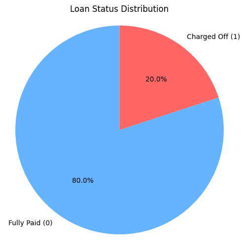

```python
import matplotlib.pyplot as plt

# charged_off 컬럼 값 개수 세기 (0: 상환, 1: 연체)
counts = data['charged_off'].value_counts()
labels = ['Fully Paid (0)', 'Charged Off (1)']
colors = ['#66b3ff', '#ff6666']

# 파이 차트 그리기
plt.figure(figsize=(6, 6))
plt.pie(counts, labels=labels, autopct='%1.1f%%', startangle=90, colors=colors)
plt.title('Loan Status Distribution')
plt.axis('equal')  # 원형 유지
plt.show()
```

## 다중공선성 계산

- VIF > 10: 심각한 다중공선성 의심
- VIF > 5: 다중공선성 가능성 있음

```python
data2 = data.copy()
data2['issue_d'] = pd.to_datetime(data2['issue_d'], format='%b-%Y')
data2.info()
```

```
<class 'pandas.core.frame.DataFrame'>
RangeIndex: 1345310 entries, 0 to 1345309
Columns: 122 entries, loan_amnt to application_type_Joint App
dtypes: bool(104), datetime64[ns](1), float64(13), int64(4)
memory usage: 318.2 MB
```

```python
data2.select_dtypes(include='bool').columns
```

```
Index(['sub_grade_A2', 'sub_grade_A3', 'sub_grade_A4', 'sub_grade_A5',
       'sub_grade_B1', 'sub_grade_B2', 'sub_grade_B3', 'sub_grade_B4',
       'sub_grade_B5', 'sub_grade_C1',
       ...
       'addr_state_TX', 'addr_state_UT', 'addr_state_VA', 'addr_state_VT',
       'addr_state_WA', 'addr_state_WI', 'addr_state_WV', 'addr_state_WY',
       'initial_list_status_w', 'application_type_Joint App'],
      dtype='object', length=104)
```

```python
# import pandas as pd
# from statsmodels.stats.outliers_influence import variance_inflation_factor
# from sklearn.preprocessing import StandardScaler

# # 1. 분석 대상에서 불필요한 열 제거
# data2_vif = data2.drop(columns=['charged_off', 'issue_d'])

# # 2. 결측치 제거
# data2_vif = data2_vif.dropna()

# # 3. 표본 5만 건만 사용
# sampled_data = data2_vif.sample(n=50000, random_state=42)

# # 4. 스케일링
# scaler = StandardScaler()
# X_scaled = scaler.fit_transform(sampled_data)

# # 5. VIF 계산
# vif_data = pd.DataFrame()
# vif_data["feature"] = sampled_data.columns  # ✅ 표본 데이터의 컬럼명 사용
# vif_data["VIF"] = [variance_inflation_factor(X_scaled, i) for i in range(X_scaled.shape[1])]

# # 6. VIF 정렬해서 출력
# vif_data = vif_data.sort_values(by="VIF", ascending=False)
# print(vif_data)
```

```python
# import pandas as pd
# import numpy as np
# from statsmodels.stats.outliers_influence import variance_inflation_factor
# from sklearn.preprocessing import StandardScaler

# # 1. 불필요한 열 제거
# data2_vif2 = data2.drop(columns=['charged_off', 'issue_d'])

# # 2. 결측치 제거
# data2_vif2 = data2_vif2.dropna()

# # 3. 표본 추출
# sampled_data2 = data2_vif2.sample(n=50000, random_state=42)

# # 4. 상수값만 가진 컬럼 제거
# sampled_data2 = sampled_data2.loc[:, sampled_data2.std() > 0]

# # 5. 스케일링
# scaler2 = StandardScaler()
# X_scaled2 = scaler2.fit_transform(sampled_data2)
# columns2 = sampled_data2.columns.tolist()

# # 6. VIF 제거 루프
# iteration2 = 1
# while True:
#     vif2 = [variance_inflation_factor(X_scaled2, i) for i in range(X_scaled2.shape[1])]
#     vif_data2 = pd.DataFrame({'feature': columns2, 'VIF': vif2})

#     max_vif2 = vif_data2['VIF'].max()
#     max_vif_feature2 = vif_data2.loc[vif_data2['VIF'].idxmax(), 'feature']

#     print(f"\n✅ Iteration {iteration2} - 변수 개수: {len(columns2)}")
#     print(vif_data2.sort_values(by='VIF', ascending=False).head(5))  # 상위 5개 출력

#     if max_vif2 > 10:
#         print(f"⚠️  제거: '{max_vif_feature2}' (VIF={max_vif2:.2f})")
#         columns2.remove(max_vif_feature2)
#         sampled_data2 = sampled_data2[columns2]
#         X_scaled2 = scaler2.fit_transform(sampled_data2)
#         iteration2 += 1
#     else:
#         print("🎉 모든 변수의 VIF가 10 이하입니다.")
#         break

# # 7. 최종 VIF 출력
# print("\n📌 최종 VIF 결과:")
# final_vif_data2 = pd.DataFrame({
#     'feature': columns2,
#     'VIF': [variance_inflation_factor(X_scaled2, i) for i in range(X_scaled2.shape[1])]
# }).sort_values(by='VIF', ascending=False)

# print(final_vif_data2)
```

```python
# import pandas as pd
# import numpy as np
# from statsmodels.stats.outliers_influence import variance_inflation_factor
# from sklearn.preprocessing import StandardScaler

# # 1. 불필요한 열 제거
# data2_vif2 = data2.drop(columns=['charged_off', 'issue_d'])

# # 2. 결측치 제거
# data2_vif2 = data2_vif2.dropna()

# # 3. 표본 추출
# sampled_data2 = data2_vif2.sample(n=50000, random_state=42)

# # 4. 상수값만 가진 컬럼 제거
# sampled_data2 = sampled_data2.loc[:, sampled_data2.std() > 0]

# # 5. 스케일링
# scaler2 = StandardScaler()
# X_scaled2 = scaler2.fit_transform(sampled_data2)
# columns2 = sampled_data2.columns.tolist()

# # 6. VIF 계산
# vif_values2 = [variance_inflation_factor(X_scaled2, i) for i in range(X_scaled2.shape[1])]
# vif_data2 = pd.DataFrame({
#     'feature': columns2,
#     'VIF': vif_values2
# }).sort_values(by='VIF', ascending=False)

# # 7. 저장
# vif_data2.to_csv("vif_result_sorted.csv", index=False)
# print("✅ VIF 결과가 'vif_result_sorted.csv' 파일로 저장되었습니다.")
```

### (3) 훈련/테스트 데이터 나누기

```python
data['issue_d'].sample(5)
```

```
1067255    Aug-2013
857232     Mar-2014
557370     Apr-2017
423503     Aug-2017
390231     Jan-2018
Name: issue_d, dtype: object
```

```python
data['issue_d'].isnull().any()
```

```
False
```

```python
data['issue_d'] = pd.to_datetime(data['issue_d'])
```

```python
data['issue_d'].sample(5)
```

```
1084880   2013-07-01
1152465   2012-10-01
819188    2014-05-01
528496    2017-06-01
1216730   2016-08-01
Name: issue_d, dtype: datetime64[ns]
```

```python
data['issue_d'].describe()
```

```
count                          1345310
mean     2015-06-06 17:48:20.835048960
min                2007-06-01 00:00:00
25%                2014-07-01 00:00:00
50%                2015-08-01 00:00:00
75%                2016-07-01 00:00:00
max                2018-12-01 00:00:00
Name: issue_d, dtype: object
```

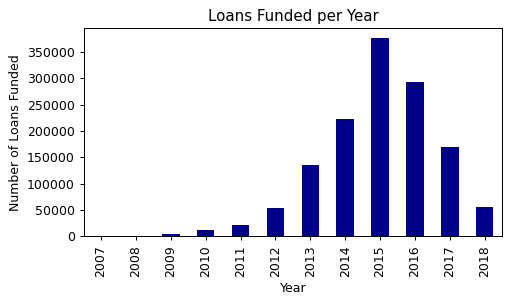

```python
plt.figure(figsize=(6,3), dpi=90)
data['issue_d'].dt.year.value_counts().sort_index().plot.bar(color='darkblue')
plt.xlabel('Year')
plt.ylabel('Number of Loans Funded')
plt.title('Loans Funded per Year')
```

```python
loans_train = data.loc[data['issue_d'] <  data['issue_d'].quantile(0.9)]
loans_test =  data.loc[data['issue_d'] >= data['issue_d'].quantile(0.9)]
```

```python
print('Number of loans in the partition:   ', loans_train.shape[0] + loans_test.shape[0])
print('Number of loans in the full dataset:', data.shape[0])
```

```
Number of loans in the partition:    1345310
Number of loans in the full dataset: 1345310
```

```python
loans_test.shape[0] / data.shape[0]
```

```
0.11111639696426846
```

```python
del data
```

```python
loans_train['issue_d'].describe()
```

```
count                          1195824
mean     2015-02-14 03:13:47.495684864
min                2007-06-01 00:00:00
25%                2014-05-01 00:00:00
50%                2015-06-01 00:00:00
75%                2016-03-01 00:00:00
max                2017-05-01 00:00:00
Name: issue_d, dtype: object
```

```python
loans_test['issue_d'].describe()
```

```
count                           149486
mean     2017-11-23 13:15:22.119796992
min                2017-06-01 00:00:00
25%                2017-08-01 00:00:00
50%                2017-11-01 00:00:00
75%                2018-03-01 00:00:00
max                2018-12-01 00:00:00
Name: issue_d, dtype: object
```

```python
loans_train.drop('issue_d', axis=1, inplace=True)
loans_test.drop('issue_d', axis=1, inplace=True)
```

```python
y_train = loans_train['charged_off']
y_test = loans_test['charged_off']
```

```python
X_train = loans_train.drop('charged_off', axis=1)
X_test = loans_test.drop('charged_off', axis=1)
```

```python
del loans_train, loans_test
```

```python
# 입력 데이터 (Features)
#X_train.to_csv("lendingclub_processed1_X_train.csv", index=False, encoding='utf-8')
#X_test.to_csv("lendingclub_processed1_X_test.csv", index=False, encoding='utf-8')

# 타깃 변수 (Labels)
#y_train.to_csv("lendingclub_processed1_y_train.csv", index=False, encoding='utf-8')
#y_test.to_csv("lendingclub_processed1_y_test.csv", index=False, encoding='utf-8')
```

## target(charged_off)과 피쳐 간의 선형 상관관계 분석

```python
# linear_dep = pd.DataFrame()
```

피어슨 상관계수

- -1 ~ 1 사이 값으로, 절댓값이 클수록 강한 선형 관계

```python
# for col in X_train.columns:
#     linear_dep.loc[col, 'pearson_corr'] = X_train[col].corr(y_train)
# linear_dep['abs_pearson_corr'] = abs(linear_dep['pearson_corr'])
```

F-통계량

- (각 변수와 charged_off 간 분산분석(ANOVA)을 수행)
- F 값은 그룹 간 차이가 유의미한지를 나타냄
- p_value는 그 유의성의 확률값(작을수록 유의미함)
- (결측치가 없는 부분만 사용해 계산)

```python
# from sklearn.feature_selection import f_classif
# for col in X_train.columns:
#     mask = X_train[col].notnull()
#     (linear_dep.loc[col, 'F'], linear_dep.loc[col, 'p_value']) = f_classif(pd.DataFrame(X_train.loc[mask, col]), y_train.loc[mask])
```

- 피어슨 상관계수의 절대값에 따라 정렬

```python
# linear_dep.sort_values('abs_pearson_corr', ascending=False, inplace=True)
# linear_dep.drop('abs_pearson_corr', axis=1, inplace=True)
```

```python
# # index 리셋
# linear_dep.reset_index(inplace=True)
# linear_dep.rename(columns={'index':'variable'}, inplace=True)
```

- target과 상관관계 강한 상위 20개 변수

```python
# linear_dep.head(20)
```

- target과 상관관계 약한 하위 20개 변수

```python
# linear_dep.tail(20)
```

- 상관관계가 높 변수: 이자율, 대출 기간(만기), FICO 점수, 소득 대비 부채 비율, 모기지 건수, 소득, 대출 등급, 대출 금액
- 상관관계 낮은 변수: 대출자의 거주 상태, 회전 잔액 및 대출 목적

```python
#linear_dep.to_csv("lendingclub_processed1_linear_dep.csv", index=False, encoding='utf-8')
```

## 모델 훈련 및 테스트

```python
from sklearn.pipeline import Pipeline
from sklearn.preprocessing import StandardScaler
from sklearn.impute import SimpleImputer
from sklearn.discriminant_analysis import LinearDiscriminantAnalysis
from sklearn.model_selection import GridSearchCV
```

### (4) 하이퍼파라미터 조정 or 다른 모델 선택

LightGBM (추천도 ★★★★★)

- ✅ 대용량 데이터에 최적화 (GPU 사용 가능)
- ✅ 범주형 변수 자동 처리
- ✅ 결측값 내재 처리
- ✅ 학습 속도 빠르고 성능 우수
- 🎯 AUROC 0.75~0.85 이상 기대 가능
- optuna.integration.lightgbm으로 자동 튜닝도 간편

```
Training until validation scores don't improve for 50 rounds
[100]	train's auc: 0.725678	train's binary_logloss: 0.445987	valid's auc: 0.717626	valid's binary_logloss: 0.455025
[200]	train's auc: 0.730895	train's binary_logloss: 0.443274	valid's auc: 0.720211	valid's binary_logloss: 0.453786
[300]	train's auc: 0.734861	train's binary_logloss: 0.441211	valid's auc: 0.721505	valid's binary_logloss: 0.453059
[400]	train's auc: 0.73824	train's binary_logloss: 0.439453	valid's auc: 0.722188	valid's binary_logloss: 0.452684
[500]	train's auc: 0.74148	train's binary_logloss: 0.437762	valid's auc: 0.722854	valid's binary_logloss: 0.452379
Early stopping, best iteration is:
[522]	train's auc: 0.742101	train's binary_logloss: 0.437407	valid's auc: 0.722993	valid's binary_logloss: 0.452326
✅ Test ROC AUC (roc_auc_40): 0.7230
✅ Test PR AUC (pr_auc_40): 0.3869
✅ Test Precision (precision_40): 0.5117
✅ Test Recall (recall_40): 0.1205
✅ Test F1 Score (f1_40): 0.1951

📊 Confusion Matrix (cm_40):
            Predicted Neg  Predicted Pos
Actual Neg         115720           3483
Actual Pos          26633           3650
```

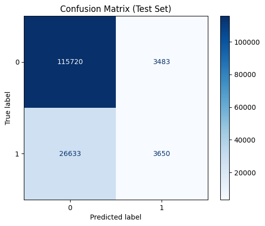

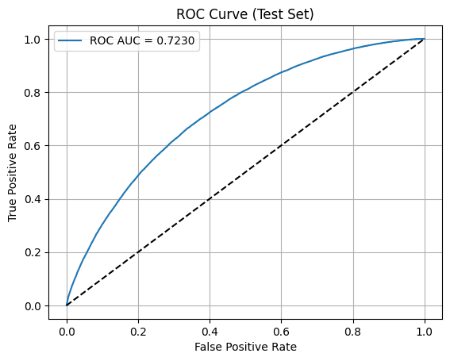

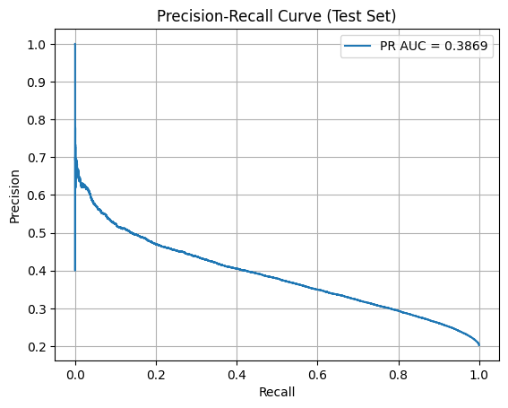

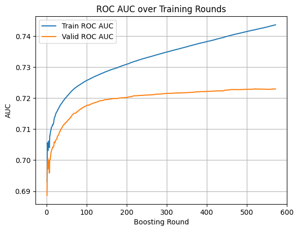

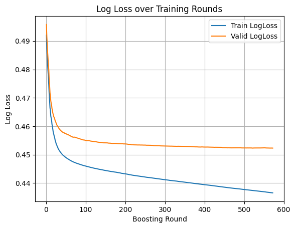

```python
import lightgbm as lgb
from lightgbm import early_stopping, log_evaluation, record_evaluation
import matplotlib.pyplot as plt
import numpy as np
import pandas as pd
from sklearn.metrics import (
    roc_auc_score, average_precision_score,
    precision_score, recall_score, f1_score,
    confusion_matrix, ConfusionMatrixDisplay,
    roc_curve, precision_recall_curve,
    log_loss
)

# LightGBM Dataset 생성
dtrain_40 = lgb.Dataset(X_train, label=y_train)
dvalid_40 = lgb.Dataset(X_test, label=y_test)

# 최적 하이퍼파라미터 (넘버링 40)
best_params_40 = {
    "objective": "binary",
    "metric": ["auc", "binary_logloss"],  # ✅ 추가
    "verbosity": -1,
    "boosting_type": "gbdt",
    "n_jobs": -1,
    "feature_pre_filter": False,
    "lambda_l1": 0.0,
    "lambda_l2": 0.0,
    "num_leaves": 31,
    "feature_fraction": 0.4,
    "bagging_fraction": 1.0,
    "bagging_freq": 0,
    "min_child_samples": 20,
}

evals_result_40 = {}  # 기록용 딕셔너리

model_40 = lgb.train(
    best_params_40,
    train_set=dtrain_40,
    valid_sets=[dtrain_40, dvalid_40],
    valid_names=['train', 'valid'],
    num_boost_round=1000,
    callbacks=[
        early_stopping(stopping_rounds=50),
        log_evaluation(period=100),
        record_evaluation(evals_result_40)  # ✅ 여기에 기록 콜백 추가
    ]
)

# 테스트 데이터 예측 (확률)
y_pred_prob_40 = model_40.predict(X_test)

# 이진 예측값 (threshold=0.5)
y_pred_40 = (y_pred_prob_40 >= 0.5).astype(int)

# 다양한 평가 지표 계산
roc_auc_40 = roc_auc_score(y_test, y_pred_prob_40)
pr_auc_40 = average_precision_score(y_test, y_pred_prob_40)
precision_40 = precision_score(y_test, y_pred_40)
recall_40 = recall_score(y_test, y_pred_40)
f1_40 = f1_score(y_test, y_pred_40)
cm_40 = confusion_matrix(y_test, y_pred_40)

print(f"✅ Test ROC AUC (roc_auc_40): {roc_auc_40:.4f}")
print(f"✅ Test PR AUC (pr_auc_40): {pr_auc_40:.4f}")
print(f"✅ Test Precision (precision_40): {precision_40:.4f}")
print(f"✅ Test Recall (recall_40): {recall_40:.4f}")
print(f"✅ Test F1 Score (f1_40): {f1_40:.4f}")
print("\n📊 Confusion Matrix (cm_40):")
print(pd.DataFrame(
    cm_40,
    columns=['Predicted Neg', 'Predicted Pos'],
    index=['Actual Neg', 'Actual Pos']
))

# Confusion Matrix 시각화
disp_40 = ConfusionMatrixDisplay(confusion_matrix=cm_40)
disp_40.plot(cmap="Blues")
plt.title("Confusion Matrix (Test Set)")
plt.show()

# ROC Curve 시각화
fpr_40, tpr_40, _ = roc_curve(y_test, y_pred_prob_40)
plt.plot(fpr_40, tpr_40, label=f"ROC AUC = {roc_auc_40:.4f}")
plt.plot([0, 1], [0, 1], 'k--')
plt.xlabel("False Positive Rate")
plt.ylabel("True Positive Rate")
plt.title("ROC Curve (Test Set)")
plt.legend()
plt.grid(True)
plt.show()

# Precision-Recall Curve 시각화
prec_40, rec_40, _ = precision_recall_curve(y_test, y_pred_prob_40)
plt.plot(rec_40, prec_40, label=f"PR AUC = {pr_auc_40:.4f}")
plt.xlabel("Recall")
plt.ylabel("Precision")
plt.title("Precision-Recall Curve (Test Set)")
plt.legend()
plt.grid(True)
plt.show()

# 훈련 시점별 평가 지표(roc_auc, logloss) 변화 선그래프 그리기

epochs_40 = range(1, len(evals_result_40['train']['auc']) + 1)

# Train/Test ROC AUC
plt.plot(epochs_40, evals_result_40['train']['auc'], label='Train ROC AUC')
plt.plot(epochs_40, evals_result_40['valid']['auc'], label='Valid ROC AUC')

plt.xlabel('Boosting Round')
plt.ylabel('AUC')
plt.title('ROC AUC over Training Rounds')
plt.legend()
plt.grid(True)
plt.show()

# Train/Test LogLoss
plt.plot(epochs_40, evals_result_40['train']['binary_logloss'], label='Train LogLoss')
plt.plot(epochs_40, evals_result_40['valid']['binary_logloss'], label='Valid LogLoss')

plt.xlabel('Boosting Round')
plt.ylabel('Log Loss')
plt.title('Log Loss over Training Rounds')
plt.legend()
plt.grid(True)
plt.show()
```

[output not shown]

[figure not shown]

[figure not shown]

[figure not shown]

[figure not shown]

[figure not shown]

[figure not shown]

```python
# import lightgbm as lgb
# from lightgbm import early_stopping, log_evaluation, record_evaluation
# import matplotlib.pyplot as plt
# import numpy as np
# import pandas as pd
# from sklearn.decomposition import PCA
# from sklearn.metrics import (
#     roc_auc_score, average_precision_score,
#     precision_score, recall_score, f1_score,
#     confusion_matrix, ConfusionMatrixDisplay,
#     roc_curve, precision_recall_curve,
# )
# import shap
# from sklearn.impute import SimpleImputer
# from sklearn.decomposition import PCA

# # 1. 결측값 평균 대체
# imputer = SimpleImputer(strategy='mean')
# X_train_imputed = imputer.fit_transform(X_train)
# X_test_imputed = imputer.transform(X_test)

# # 2. PCA 적용
# n_components = 50
# pca = PCA(n_components=n_components, random_state=42)
# X_train_reduced = pca.fit_transform(X_train_imputed)
# X_test_reduced = pca.transform(X_test_imputed)

# # ✅ PCA 적용 후 LGB용 Dataset 정의
# dtrain = lgb.Dataset(X_train_reduced, label=y_train)
# dvalid = lgb.Dataset(X_test_reduced, label=y_test)

# # 3. 하이퍼파라미터 설정
# best_params = {
#     "objective": "binary",
#     "metric": ["auc", "binary_logloss"],
#     "verbosity": -1,
#     "boosting_type": "gbdt",
#     "n_jobs": -1,
#     "feature_pre_filter": False,
#     "lambda_l1": 0.0,
#     "lambda_l2": 0.0,
#     "num_leaves": 31,
#     "feature_fraction": 0.4,
#     "bagging_fraction": 1.0,
#     "bagging_freq": 0,
#     "min_child_samples": 20,
# }

# evals_result_41 = {}

# model_41 = lgb.train(
#     best_params,
#     train_set=dtrain,
#     valid_sets=[dtrain, dvalid],
#     valid_names=['train', 'valid'],
#     num_boost_round=1000,
#     callbacks=[
#         early_stopping(stopping_rounds=50),
#         log_evaluation(period=100),
#         record_evaluation(evals_result_41)
#     ]
# )

# # 5. 테스트 데이터 예측 및 평가
# y_pred_prob_41 = model_41.predict(X_test_reduced)
# y_pred_41 = (y_pred_prob_41 >= 0.5).astype(int)

# roc_auc_41 = roc_auc_score(y_test, y_pred_prob_41)
# pr_auc_41 = average_precision_score(y_test, y_pred_prob_41)
# precision_41 = precision_score(y_test, y_pred_41)
# recall_41 = recall_score(y_test, y_pred_41)
# f1_41 = f1_score(y_test, y_pred_41)
# cm_41 = confusion_matrix(y_test, y_pred_41)

# print(f"✅ Test ROC AUC: {roc_auc_41:.4f}")
# print(f"✅ Test PR AUC: {pr_auc_41:.4f}")
# print(f"✅ Test Precision: {precision_41:.4f}")
# print(f"✅ Test Recall: {recall_41:.4f}")
# print(f"✅ Test F1 Score: {f1_41:.4f}")
# print("\n📊 Confusion Matrix:")
# print(pd.DataFrame(cm_41, columns=['Predicted Neg', 'Predicted Pos'], index=['Actual Neg', 'Actual Pos']))

# # 6. Confusion Matrix 시각화
# disp_41 = ConfusionMatrixDisplay(confusion_matrix=cm_41)
# disp_41.plot(cmap="Blues")
# plt.title("Confusion Matrix (Test Set 41)")
# plt.show()

# # 7. ROC Curve 시각화
# fpr_41, tpr_41, _ = roc_curve(y_test, y_pred_prob_41)
# plt.plot(fpr_41, tpr_41, label=f"ROC AUC = {roc_auc_41:.4f}")
# plt.plot([0, 1], [0, 1], 'k--')
# plt.xlabel("False Positive Rate")
# plt.ylabel("True Positive Rate")
# plt.title("ROC Curve (Test Set 41)")
# plt.legend()
# plt.grid(True)
# plt.show()

# # 8. Precision-Recall Curve 시각화
# prec_41, rec_41, _ = precision_recall_curve(y_test, y_pred_prob_41)
# plt.plot(rec_41, prec_41, label=f"PR AUC = {pr_auc_41:.4f}")
# plt.xlabel("Recall")
# plt.ylabel("Precision")
# plt.title("Precision-Recall Curve (Test Set 41)")
# plt.legend()
# plt.grid(True)
# plt.show()

# # 9. 훈련 시점별 평가 지표 시각화
# epochs_41 = range(1, len(evals_result_41['train']['auc']) + 1)
# plt.plot(epochs_41, evals_result_41['train']['auc'], label='Train ROC AUC')
# plt.plot(epochs_41, evals_result_41['valid']['auc'], label='Valid ROC AUC')
# plt.xlabel('Boosting Round')
# plt.ylabel('AUC')
# plt.title('ROC AUC over Training Rounds (Model 41)')
# plt.legend()
# plt.grid(True)
# plt.show()

# plt.plot(epochs_41, evals_result_41['train']['binary_logloss'], label='Train LogLoss')
# plt.plot(epochs_41, evals_result_41['valid']['binary_logloss'], label='Valid LogLoss')
# plt.xlabel('Boosting Round')
# plt.ylabel('Log Loss')
# plt.title('Log Loss over Training Rounds (Model 41)')
# plt.legend()
# plt.grid(True)
# plt.show()

# # 10. Feature Importance 시각화 (Gain 기준)
# lgb.plot_importance(model_41, max_num_features=20, importance_type='gain')
# plt.title("LightGBM Feature Importance (Gain, Model 41)")
# plt.show()

# # 11. SHAP 값 계산 및 요약 플롯
# explainer_41 = shap.TreeExplainer(model_41)
# shap_values_41 = explainer_41.shap_values(X_train_reduced)

# shap.summary_plot(shap_values_41, X_train_reduced, feature_names=[f"PC{i+1}" for i in range(n_components)])

# # 12. SHAP 절댓값 평균 상위 20개 변수 선택
# mean_shap = np.abs(shap_values).mean(axis=0)
# top20_idx = np.argsort(mean_shap)[-20:]
# X_train_selected = X_train_reduced[:, top20_idx]
# X_test_selected = X_test_reduced[:, top20_idx]

# # 13. 선택 변수로 재학습
# mean_shap_41 = np.abs(shap_values_41).mean(axis=0)
# top20_idx_41 = np.argsort(mean_shap_41)[-20:]
# X_train_selected_41 = X_train_reduced[:, top20_idx_41]
# X_test_selected_41 = X_test_reduced[:, top20_idx_41]

# dtrain_sel_41 = lgb.Dataset(X_train_selected_41, label=y_train)
# dvalid_sel_41 = lgb.Dataset(X_test_selected_41, label=y_test)

# model_sel_41 = lgb.train(
#     best_params,
#     train_set=dtrain_sel_41,
#     valid_sets=[dtrain_sel_41, dvalid_sel_41],
#     valid_names=['train', 'valid'],
#     num_boost_round=1000,
#     callbacks=[
#         early_stopping(stopping_rounds=50),
#         log_evaluation(period=100),
#     ]
# )

# # 14. 재학습 모델 평가 및 시각화
# y_pred_prob_sel_41 = model_sel_41.predict(X_test_selected_41)
# y_pred_sel_41 = (y_pred_prob_sel_41 >= 0.5).astype(int)

# roc_auc_sel_41 = roc_auc_score(y_test, y_pred_prob_sel_41)
# pr_auc_sel_41 = average_precision_score(y_test, y_pred_prob_sel_41)
# precision_sel_41 = precision_score(y_test, y_pred_sel_41)
# recall_sel_41 = recall_score(y_test, y_pred_sel_41)
# f1_sel_41 = f1_score(y_test, y_pred_sel_41)
# cm_sel_41 = confusion_matrix(y_test, y_pred_sel_41)

# print(f"\n✅ Selected Features Test ROC AUC: {roc_auc_sel_41:.4f}")
# print(f"✅ Selected Features Test PR AUC: {pr_auc_sel_41:.4f}")
# print(f"✅ Selected Features Test Precision: {precision_sel_41:.4f}")
# print(f"✅ Selected Features Test Recall: {recall_sel_41:.4f}")
# print(f"✅ Selected Features Test F1 Score: {f1_sel_41:.4f}")
# print("\n📊 Selected Features Confusion Matrix:")
# print(pd.DataFrame(cm_sel_41, columns=['Predicted Neg', 'Predicted Pos'], index=['Actual Neg', 'Actual Pos']))

# # Confusion Matrix 시각화 (재학습 모델)
# disp_sel_41 = ConfusionMatrixDisplay(confusion_matrix=cm_sel_41)
# disp_sel_41.plot(cmap="Blues")
# plt.title("Confusion Matrix (Selected Features Test Set 41)")
# plt.show()

# # ROC Curve 시각화 (재학습 모델)
# fpr_sel_41, tpr_sel_41, _ = roc_curve(y_test, y_pred_prob_sel_41)
# plt.plot(fpr_sel_41, tpr_sel_41, label=f"ROC AUC = {roc_auc_sel_41:.4f}")
# plt.plot([0, 1], [0, 1], 'k--')
# plt.xlabel("False Positive Rate")
# plt.ylabel("True Positive Rate")
# plt.title("ROC Curve (Selected Features Test Set 41)")
# plt.legend()
# plt.grid(True)
# plt.show()

# # Precision-Recall Curve 시각화 (재학습 모델)
# prec_sel_41, rec_sel_41, _ = precision_recall_curve(y_test, y_pred_prob_sel_41)
# plt.plot(rec_sel_41, prec_sel_41, label=f"PR AUC = {pr_auc_sel_41:.4f}")
# plt.xlabel("Recall")
# plt.ylabel("Precision")
# plt.title("Precision-Recall Curve (Selected Features Test Set 41)")
# plt.legend()
# plt.grid(True)
# plt.show()
```

### 위에서 실행완료 안 되는 문제 수정

```
Training until validation scores don't improve for 50 rounds
[100]	train's auc: 0.722747	train's binary_logloss: 0.447463	valid's auc: 0.710356	valid's binary_logloss: 0.458243
[200]	train's auc: 0.728828	train's binary_logloss: 0.444387	valid's auc: 0.711935	valid's binary_logloss: 0.457593
[300]	train's auc: 0.733824	train's binary_logloss: 0.441881	valid's auc: 0.712116	valid's binary_logloss: 0.457542
[400]	train's auc: 0.738861	train's binary_logloss: 0.439399	valid's auc: 0.712439	valid's binary_logloss: 0.457449
Early stopping, best iteration is:
[365]	train's auc: 0.737149	train's binary_logloss: 0.44024	valid's auc: 0.712411	valid's binary_logloss: 0.457413
✅ Test ROC AUC: 0.7124
✅ Test PR AUC: 0.3714
✅ Test Precision: 0.4967
✅ Test Recall: 0.1003
✅ Test F1 Score: 0.1668

📊 Confusion Matrix:
            Predicted Neg  Predicted Pos
Actual Neg         116127           3076
Actual Pos          27247           3036
```

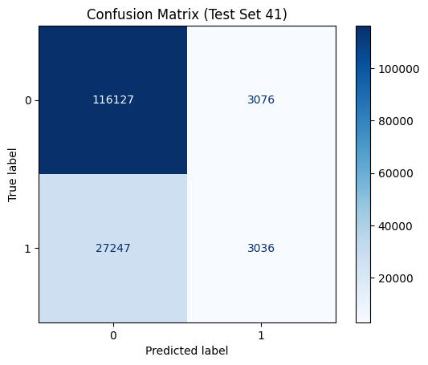

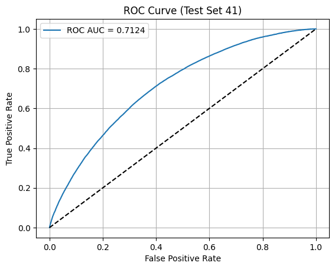

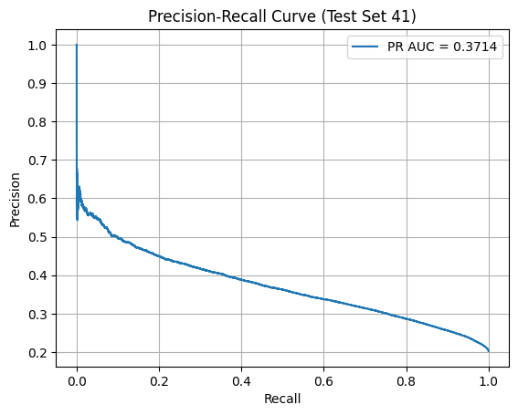

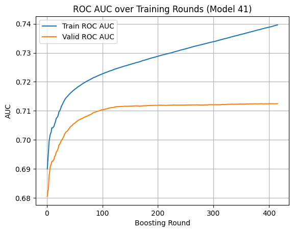

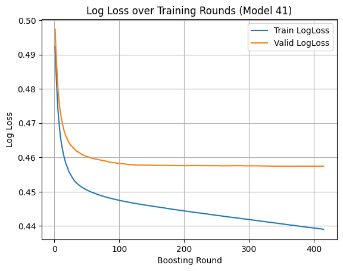

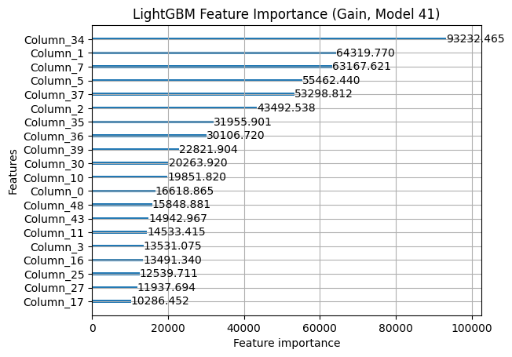

```python
# %matplotlib inline 설정 (노트북 환경 명시)
%matplotlib inline

import time
import lightgbm as lgb
from lightgbm import early_stopping, log_evaluation, record_evaluation
import matplotlib.pyplot as plt
import numpy as np
import pandas as pd
from sklearn.decomposition import PCA
from sklearn.metrics import (
    roc_auc_score, average_precision_score,
    precision_score, recall_score, f1_score,
    confusion_matrix, ConfusionMatrixDisplay,
    roc_curve, precision_recall_curve,
)
import shap
from sklearn.impute import SimpleImputer

# -- 데이터 준비 가정 --
# X_train, X_test, y_train, y_test 가 이미 준비되어 있어야 합니다.

# 1. 결측값 평균 대체
imputer = SimpleImputer(strategy='mean')
X_train_imputed = imputer.fit_transform(X_train)
X_test_imputed = imputer.transform(X_test)

# 2. PCA 적용
n_components = 50
pca = PCA(n_components=n_components, random_state=42)
X_train_reduced = pca.fit_transform(X_train_imputed)
X_test_reduced = pca.transform(X_test_imputed)

# 3. LightGBM Dataset 정의
dtrain = lgb.Dataset(X_train_reduced, label=y_train)
dvalid = lgb.Dataset(X_test_reduced, label=y_test)

# 4. 하이퍼파라미터 설정
best_params = {
    "objective": "binary",
    "metric": ["auc", "binary_logloss"],
    "verbosity": -1,
    "boosting_type": "gbdt",
    "n_jobs": -1,
    "feature_pre_filter": False,
    "lambda_l1": 0.0,
    "lambda_l2": 0.0,
    "num_leaves": 31,
    "feature_fraction": 0.4,
    "bagging_fraction": 1.0,
    "bagging_freq": 0,
    "min_child_samples": 20,
}

evals_result_41 = {}

# 시간 제한 콜백 정의 (15분 = 900초)
max_train_seconds = 900

def time_limit_callback(env):
    if not hasattr(time_limit_callback, "start_time"):
        time_limit_callback.start_time = time.time()
    elapsed = time.time() - time_limit_callback.start_time
    if elapsed > max_train_seconds:
        print(f"\n⏰ Training stopped after {elapsed:.1f} seconds (time limit reached).")
        raise lgb.callback.EarlyStopException(env.iteration)

# 5. 모델 학습 (시간 제한 콜백 포함)
model_41 = lgb.train(
    best_params,
    train_set=dtrain,
    valid_sets=[dtrain, dvalid],
    valid_names=['train', 'valid'],
    num_boost_round=1000,
    callbacks=[
        early_stopping(stopping_rounds=50),
        log_evaluation(period=100),
        record_evaluation(evals_result_41),
        time_limit_callback
    ]
)

# 6. 테스트 데이터 예측 및 평가
y_pred_prob_41 = model_41.predict(X_test_reduced)
y_pred_41 = (y_pred_prob_41 >= 0.5).astype(int)

roc_auc_41 = roc_auc_score(y_test, y_pred_prob_41)
pr_auc_41 = average_precision_score(y_test, y_pred_prob_41)
precision_41 = precision_score(y_test, y_pred_41)
recall_41 = recall_score(y_test, y_pred_41)
f1_41 = f1_score(y_test, y_pred_41)
cm_41 = confusion_matrix(y_test, y_pred_41)

print(f"✅ Test ROC AUC: {roc_auc_41:.4f}")
print(f"✅ Test PR AUC: {pr_auc_41:.4f}")
print(f"✅ Test Precision: {precision_41:.4f}")
print(f"✅ Test Recall: {recall_41:.4f}")
print(f"✅ Test F1 Score: {f1_41:.4f}")
print("\n📊 Confusion Matrix:")
print(pd.DataFrame(cm_41, columns=['Predicted Neg', 'Predicted Pos'], index=['Actual Neg', 'Actual Pos']))

# 7. 시각화 - Confusion Matrix
disp_41 = ConfusionMatrixDisplay(confusion_matrix=cm_41)
disp_41.plot(cmap="Blues")
plt.title("Confusion Matrix (Test Set 41)")
plt.show()

# 8. ROC Curve
fpr_41, tpr_41, _ = roc_curve(y_test, y_pred_prob_41)
plt.plot(fpr_41, tpr_41, label=f"ROC AUC = {roc_auc_41:.4f}")
plt.plot([0, 1], [0, 1], 'k--')
plt.xlabel("False Positive Rate")
plt.ylabel("True Positive Rate")
plt.title("ROC Curve (Test Set 41)")
plt.legend()
plt.grid(True)
plt.show()

# 9. Precision-Recall Curve
prec_41, rec_41, _ = precision_recall_curve(y_test, y_pred_prob_41)
plt.plot(rec_41, prec_41, label=f"PR AUC = {pr_auc_41:.4f}")
plt.xlabel("Recall")
plt.ylabel("Precision")
plt.title("Precision-Recall Curve (Test Set 41)")
plt.legend()
plt.grid(True)
plt.show()

# 10. 학습 과정 시각화
epochs_41 = range(1, len(evals_result_41['train']['auc']) + 1)
plt.plot(epochs_41, evals_result_41['train']['auc'], label='Train ROC AUC')
plt.plot(epochs_41, evals_result_41['valid']['auc'], label='Valid ROC AUC')
plt.xlabel('Boosting Round')
plt.ylabel('AUC')
plt.title('ROC AUC over Training Rounds (Model 41)')
plt.legend()
plt.grid(True)
plt.show()

plt.plot(epochs_41, evals_result_41['train']['binary_logloss'], label='Train LogLoss')
plt.plot(epochs_41, evals_result_41['valid']['binary_logloss'], label='Valid LogLoss')
plt.xlabel('Boosting Round')
plt.ylabel('Log Loss')
plt.title('Log Loss over Training Rounds (Model 41)')
plt.legend()
plt.grid(True)
plt.show()

# 11. Feature Importance
lgb.plot_importance(model_41, max_num_features=20, importance_type='gain')
plt.title("LightGBM Feature Importance (Gain, Model 41)")
plt.show()

# 12. SHAP 값 계산 및 시각화
explainer_41 = shap.TreeExplainer(model_41)
shap_values_41 = explainer_41.shap_values(X_train_reduced)

# SHAP summary plot (노트북에서는 %matplotlib inline 으로 충분)
shap.summary_plot(shap_values_41, X_train_reduced, feature_names=[f"PC{i+1}" for i in range(n_components)])

# 13. SHAP 절댓값 평균 기준 상위 20개 변수 선택
mean_shap_41 = np.abs(shap_values_41).mean(axis=0)
top20_idx_41 = np.argsort(mean_shap_41)[-20:]
X_train_selected_41 = X_train_reduced[:, top20_idx_41]
X_test_selected_41 = X_test_reduced[:, top20_idx_41]

# 14. 선택 변수 기반 재학습
dtrain_sel_41 = lgb.Dataset(X_train_selected_41, label=y_train)
dvalid_sel_41 = lgb.Dataset(X_test_selected_41, label=y_test)

model_sel_41 = lgb.train(
    best_params,
    train_set=dtrain_sel_41,
    valid_sets=[dtrain_sel_41, dvalid_sel_41],
    valid_names=['train', 'valid'],
    num_boost_round=1000,
    callbacks=[
        early_stopping(stopping_rounds=50),
        log_evaluation(period=100),
        time_limit_callback  # 재학습에도 시간 제한 콜백 적용 가능 (필요시)
    ]
)

# 15. 재학습 모델 평가
y_pred_prob_sel_41 = model_sel_41.predict(X_test_selected_41)
y_pred_sel_41 = (y_pred_prob_sel_41 >= 0.5).astype(int)

roc_auc_sel_41 = roc_auc_score(y_test, y_pred_prob_sel_41)
pr_auc_sel_41 = average_precision_score(y_test, y_pred_prob_sel_41)
precision_sel_41 = precision_score(y_test, y_pred_sel_41)
recall_sel_41 = recall_score(y_test, y_pred_sel_41)
f1_sel_41 = f1_score(y_test, y_pred_sel_41)
cm_sel_41 = confusion_matrix(y_test, y_pred_sel_41)

print(f"\n✅ Selected Features Test ROC AUC: {roc_auc_sel_41:.4f}")
print(f"✅ Selected Features Test PR AUC: {pr_auc_sel_41:.4f}")
print(f"✅ Selected Features Test Precision: {precision_sel_41:.4f}")
print(f"✅ Selected Features Test Recall: {recall_sel_41:.4f}")
print(f"✅ Selected Features Test F1 Score: {f1_sel_41:.4f}")
print("\n📊 Selected Features Confusion Matrix:")
print(pd.DataFrame(cm_sel_41, columns=['Predicted Neg', 'Predicted Pos'], index=['Actual Neg', 'Actual Pos']))

# 16. 재학습 모델 시각화
disp_sel_41 = ConfusionMatrixDisplay(confusion_matrix=cm_sel_41)
disp_sel_41.plot(cmap="Blues")
plt.title("Confusion Matrix (Selected Features Test Set 41)")
plt.show()

fpr_sel_41, tpr_sel_41, _ = roc_curve(y_test, y_pred_prob_sel_41)
plt.plot(fpr_sel_41, tpr_sel_41, label=f"ROC AUC = {roc_auc_sel_41:.4f}")
plt.plot([0, 1], [0, 1], 'k--')
plt.xlabel("False Positive Rate")
plt.ylabel("True Positive Rate")
plt.title("ROC Curve (Selected Features Test Set 41)")
plt.legend()
plt.grid(True)
plt.show()

prec_sel_41, rec_sel_41, _ = precision_recall_curve(y_test, y_pred_prob_sel_41)
plt.plot(rec_sel_41, prec_sel_41, label=f"PR AUC = {pr_auc_sel_41:.4f}")
plt.xlabel("Recall")
plt.ylabel("Precision")
plt.title("Precision-Recall Curve (Selected Features Test Set 41)")
plt.legend()
plt.grid(True)
plt.show()
```

[output not shown]

```
Training until validation scores don't improve for 50 rounds
[100]	train's auc: 0.718569	train's binary_logloss: 0.449363	valid's auc: 0.704039	valid's binary_logloss: 0.461673
[200]	train's auc: 0.723529	train's binary_logloss: 0.446871	valid's auc: 0.705992	valid's binary_logloss: 0.461088
[300]	train's auc: 0.72773	train's binary_logloss: 0.44483	valid's auc: 0.706433	valid's binary_logloss: 0.461017
[400]	train's auc: 0.731585	train's binary_logloss: 0.442894	valid's auc: 0.706645	valid's binary_logloss: 0.460982
Early stopping, best iteration is:
[407]	train's auc: 0.731841	train's binary_logloss: 0.442767	valid's auc: 0.706754	valid's binary_logloss: 0.460938
✅ Test ROC AUC: 0.7068
✅ Test PR AUC: 0.3669
✅ Test Precision: 0.4833
✅ Test Recall: 0.1187
✅ Test F1 Score: 0.1906

📊 Confusion Matrix:
            Predicted Neg  Predicted Pos
Actual Neg         115361           3842
Actual Pos          26689           3594
```

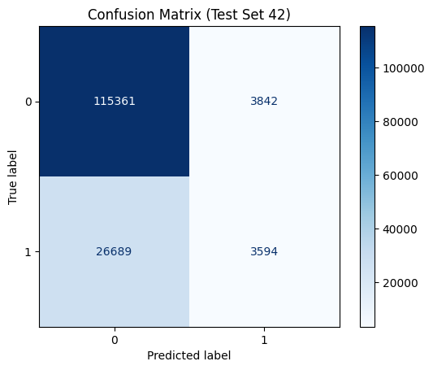

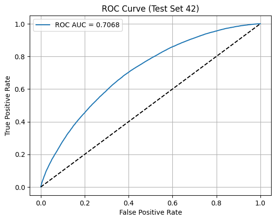

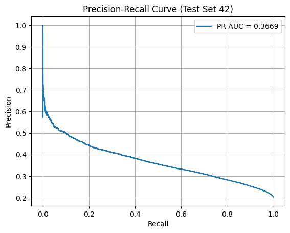

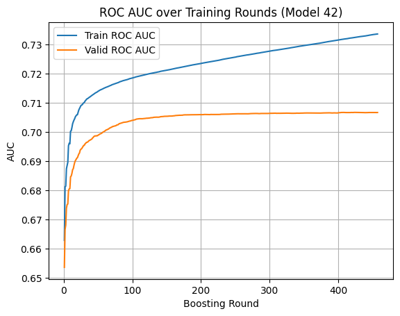

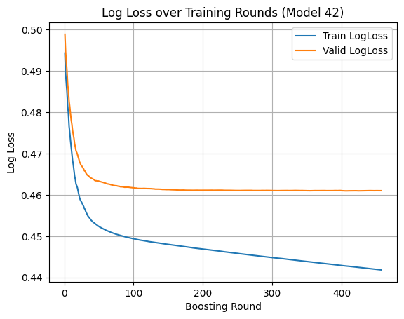

```python
# %matplotlib inline 설정 (노트북 환경 명시)
%matplotlib inline

import time
import lightgbm as lgb
from lightgbm import early_stopping, log_evaluation, record_evaluation
import matplotlib.pyplot as plt
import numpy as np
import pandas as pd
from sklearn.decomposition import PCA
from sklearn.metrics import (
    roc_auc_score, average_precision_score,
    precision_score, recall_score, f1_score,
    confusion_matrix, ConfusionMatrixDisplay,
    roc_curve, precision_recall_curve,
)
import shap
from sklearn.impute import SimpleImputer

# -- 데이터 준비 가정 --
# X_train, X_test, y_train, y_test 가 이미 준비되어 있어야 합니다.

# 1. 결측값 평균 대체
imputer = SimpleImputer(strategy='mean')
X_train_imputed = imputer.fit_transform(X_train)
X_test_imputed = imputer.transform(X_test)

# 2. SHAP 값 계산을 위한 임시 LightGBM 학습 (원본 전체 feature 사용)
dtrain_full = lgb.Dataset(X_train_imputed, label=y_train)

params_shap = {
    "objective": "binary",
    "metric": "auc",
    "verbosity": -1,
    "boosting_type": "gbdt",
    "num_leaves": 31,
    "feature_fraction": 0.8,
    "bagging_fraction": 0.8,
    "bagging_freq": 5,
    "seed": 42,
    "n_jobs": -1,
}

shap_model = lgb.train(
    params_shap,
    dtrain_full,
    num_boost_round=100,
    valid_sets=[dtrain_full],
    valid_names=['train'],
    callbacks=[lgb.log_evaluation(period=0)]  # 로그 출력 없음
)

explainer = shap.TreeExplainer(shap_model)
shap_values = explainer.shap_values(X_train_imputed)

# 3. SHAP 절댓값 평균 기준 상위 50개 변수 선택
mean_abs_shap = np.abs(shap_values).mean(axis=0)
top50_idx = np.argsort(mean_abs_shap)[-50:]
top50_features = top50_idx  # 인덱스 리스트

X_train_top50 = X_train_imputed[:, top50_features]
X_test_top50 = X_test_imputed[:, top50_features]

# 4. PCA 적용 (n_components=20)
pca = PCA(n_components=20, random_state=42)
X_train_pca = pca.fit_transform(X_train_top50)
X_test_pca = pca.transform(X_test_top50)

# 5. LightGBM 학습용 Dataset 정의
dtrain = lgb.Dataset(X_train_pca, label=y_train)
dvalid = lgb.Dataset(X_test_pca, label=y_test)

# 6. 하이퍼파라미터 설정 (기존 파라미터 재활용)
best_params = {
    "objective": "binary",
    "metric": ["auc", "binary_logloss"],
    "verbosity": -1,
    "boosting_type": "gbdt",
    "n_jobs": -1,
    "feature_pre_filter": False,
    "lambda_l1": 0.0,
    "lambda_l2": 0.0,
    "num_leaves": 31,
    "feature_fraction": 0.4,
    "bagging_fraction": 1.0,
    "bagging_freq": 0,
    "min_child_samples": 20,
}

evals_result_42 = {}

# 7. 시간 제한 콜백 정의 (10분 = 600초)
max_train_seconds = 600

def time_limit_callback(env):
    if not hasattr(time_limit_callback, "start_time"):
        time_limit_callback.start_time = time.time()
    elapsed = time.time() - time_limit_callback.start_time
    if elapsed > max_train_seconds:
        print(f"\n⏰ Training stopped after {elapsed:.1f} seconds (time limit reached).")
        raise lgb.callback.EarlyStopException(env.iteration)

# 8. 모델 학습 (model_42)
model_42 = lgb.train(
    best_params,
    train_set=dtrain,
    valid_sets=[dtrain, dvalid],
    valid_names=['train', 'valid'],
    num_boost_round=1000,
    callbacks=[
        early_stopping(stopping_rounds=50),
        log_evaluation(period=100),
        record_evaluation(evals_result_42),
        time_limit_callback,
    ]
)

# 9. 테스트 데이터 예측 및 평가
y_pred_prob_42 = model_42.predict(X_test_pca)
y_pred_42 = (y_pred_prob_42 >= 0.5).astype(int)

roc_auc_42 = roc_auc_score(y_test, y_pred_prob_42)
pr_auc_42 = average_precision_score(y_test, y_pred_prob_42)
precision_42 = precision_score(y_test, y_pred_42)
recall_42 = recall_score(y_test, y_pred_42)
f1_42 = f1_score(y_test, y_pred_42)
cm_42 = confusion_matrix(y_test, y_pred_42)

print(f"✅ Test ROC AUC: {roc_auc_42:.4f}")
print(f"✅ Test PR AUC: {pr_auc_42:.4f}")
print(f"✅ Test Precision: {precision_42:.4f}")
print(f"✅ Test Recall: {recall_42:.4f}")
print(f"✅ Test F1 Score: {f1_42:.4f}")
print("\n📊 Confusion Matrix:")
print(pd.DataFrame(cm_42, columns=['Predicted Neg', 'Predicted Pos'], index=['Actual Neg', 'Actual Pos']))

# 10. 시각화 - Confusion Matrix
disp_42 = ConfusionMatrixDisplay(confusion_matrix=cm_42)
disp_42.plot(cmap="Blues")
plt.title("Confusion Matrix (Test Set 42)")
plt.show()

# 11. ROC Curve
fpr_42, tpr_42, _ = roc_curve(y_test, y_pred_prob_42)
plt.plot(fpr_42, tpr_42, label=f"ROC AUC = {roc_auc_42:.4f}")
plt.plot([0, 1], [0, 1], 'k--')
plt.xlabel("False Positive Rate")
plt.ylabel("True Positive Rate")
plt.title("ROC Curve (Test Set 42)")
plt.legend()
plt.grid(True)
plt.show()

# 12. Precision-Recall Curve
prec_42, rec_42, _ = precision_recall_curve(y_test, y_pred_prob_42)
plt.plot(rec_42, prec_42, label=f"PR AUC = {pr_auc_42:.4f}")
plt.xlabel("Recall")
plt.ylabel("Precision")
plt.title("Precision-Recall Curve (Test Set 42)")
plt.legend()
plt.grid(True)
plt.show()

# 13. 학습 과정 시각화
epochs_42 = range(1, len(evals_result_42['train']['auc']) + 1)
plt.plot(epochs_42, evals_result_42['train']['auc'], label='Train ROC AUC')
plt.plot(epochs_42, evals_result_42['valid']['auc'], label='Valid ROC AUC')
plt.xlabel('Boosting Round')
plt.ylabel('AUC')
plt.title('ROC AUC over Training Rounds (Model 42)')
plt.legend()
plt.grid(True)
plt.show()

plt.plot(epochs_42, evals_result_42['train']['binary_logloss'], label='Train LogLoss')
plt.plot(epochs_42, evals_result_42['valid']['binary_logloss'], label='Valid LogLoss')
plt.xlabel('Boosting Round')
plt.ylabel('Log Loss')
plt.title('Log Loss over Training Rounds (Model 42)')
plt.legend()
plt.grid(True)
plt.show()
```

## LightGBM + SHAP 중요 변수 선별 (PCA 미적용)

```
Training until validation scores don't improve for 50 rounds
[100]	train's auc: 0.725324	train's binary_logloss: 0.446218	valid's auc: 0.716477	valid's binary_logloss: 0.455712
[200]	train's auc: 0.730172	train's binary_logloss: 0.443689	valid's auc: 0.718976	valid's binary_logloss: 0.45467
[300]	train's auc: 0.733711	train's binary_logloss: 0.44182	valid's auc: 0.719745	valid's binary_logloss: 0.454279
[400]	train's auc: 0.737142	train's binary_logloss: 0.440052	valid's auc: 0.720163	valid's binary_logloss: 0.454048
[500]	train's auc: 0.740359	train's binary_logloss: 0.438394	valid's auc: 0.720579	valid's binary_logloss: 0.453849
Early stopping, best iteration is:
[518]	train's auc: 0.740836	train's binary_logloss: 0.438144	valid's auc: 0.720629	valid's binary_logloss: 0.453835
✅ Test ROC AUC (roc_auc_43): 0.7206
✅ Test PR AUC (pr_auc_43): 0.3828
✅ Test Precision (precision_43): 0.4983
✅ Test Recall (recall_43): 0.1290
✅ Test F1 Score (f1_43): 0.2050

📊 Confusion Matrix (cm_43):
            Predicted Neg  Predicted Pos
Actual Neg         115269           3934
Actual Pos          26376           3907
```

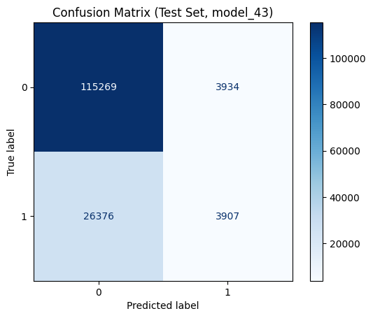

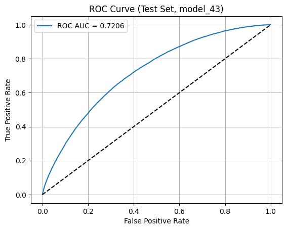

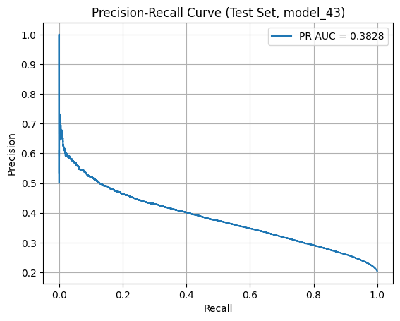

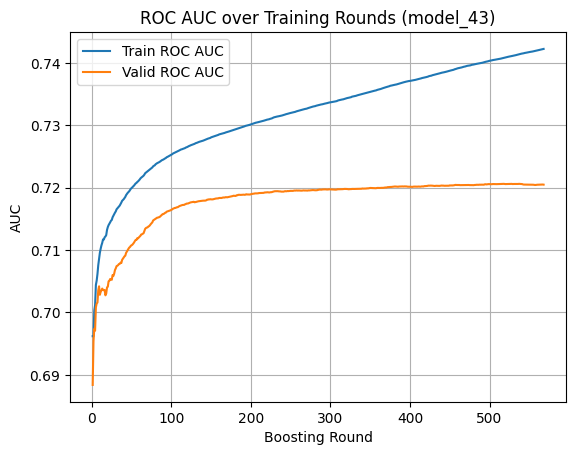

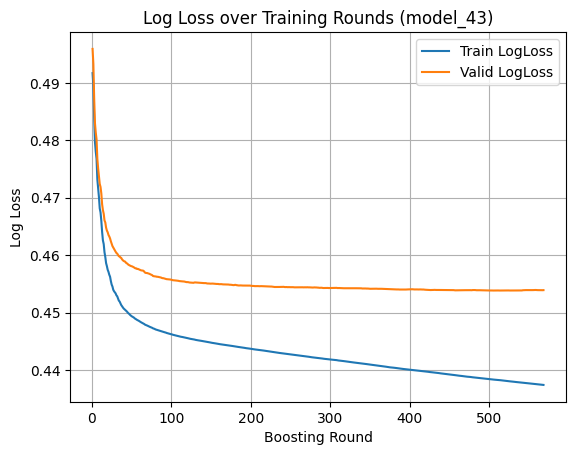

```python
import time
import lightgbm as lgb
from lightgbm import early_stopping, log_evaluation, record_evaluation
import shap
import numpy as np
import pandas as pd
import matplotlib.pyplot as plt
from sklearn.impute import SimpleImputer
from sklearn.metrics import (
    roc_auc_score, average_precision_score,
    precision_score, recall_score, f1_score,
    confusion_matrix, ConfusionMatrixDisplay,
    roc_curve, precision_recall_curve
)

# --- 결측치 처리 ---
imputer = SimpleImputer(strategy='mean')
X_train_imp = imputer.fit_transform(X_train)
X_test_imp = imputer.transform(X_test)

# --- SHAP 기반 중요 변수 상위 50개 선별 ---
shap_model_43 = lgb.train(
    {
        "objective": "binary",
        "metric": "auc",
        "verbosity": -1,
        "boosting_type": "gbdt",
        "num_leaves": 31,
        "feature_fraction": 0.8,
        "bagging_fraction": 0.8,
        "bagging_freq": 5,
        "seed": 42,
        "n_jobs": -1,
    },
    lgb.Dataset(X_train_imp, label=y_train),
    num_boost_round=100
)

explainer_43 = shap.TreeExplainer(shap_model_43)
shap_values_43 = explainer_43.shap_values(X_train_imp)
mean_abs_shap_43 = np.abs(shap_values_43).mean(axis=0)
top_50_idx_43 = np.argsort(mean_abs_shap_43)[-50:]

X_train_43 = X_train_imp[:, top_50_idx_43]
X_test_43 = X_test_imp[:, top_50_idx_43]

# --- 모델 학습 파라미터 (넘버링 43) ---
best_params_43 = {
    "objective": "binary",
    "metric": ["auc", "binary_logloss"],
    "verbosity": -1,
    "boosting_type": "gbdt",
    "n_jobs": -1,
    "feature_pre_filter": False,
    "lambda_l1": 0.0,
    "lambda_l2": 0.0,
    "num_leaves": 31,
    "feature_fraction": 0.4,
    "bagging_fraction": 1.0,
    "bagging_freq": 0,
    "min_child_samples": 20,
}

dtrain_43 = lgb.Dataset(X_train_43, label=y_train)
dvalid_43 = lgb.Dataset(X_test_43, label=y_test)
evals_result_43 = {}

max_seconds_43 = 600  # 10분 제한

def timeout_callback_43(env):
    if not hasattr(timeout_callback_43, "start_time"):
        timeout_callback_43.start_time = time.time()
    if time.time() - timeout_callback_43.start_time > max_seconds_43:
        print(f"\n⏰ Early stopped after {time.time() - timeout_callback_43.start_time:.1f}s")
        raise lgb.callback.EarlyStopException(env.iteration)

model_43 = lgb.train(
    best_params_43,
    train_set=dtrain_43,
    valid_sets=[dtrain_43, dvalid_43],
    valid_names=['train', 'valid'],
    num_boost_round=1000,
    callbacks=[
        early_stopping(50),
        log_evaluation(100),
        record_evaluation(evals_result_43),
        timeout_callback_43
    ]
)

# --- 예측 및 평가 ---
y_pred_prob_43 = model_43.predict(X_test_43)
y_pred_43 = (y_pred_prob_43 >= 0.5).astype(int)

roc_auc_43 = roc_auc_score(y_test, y_pred_prob_43)
pr_auc_43 = average_precision_score(y_test, y_pred_prob_43)
precision_43 = precision_score(y_test, y_pred_43)
recall_43 = recall_score(y_test, y_pred_43)
f1_43 = f1_score(y_test, y_pred_43)
cm_43 = confusion_matrix(y_test, y_pred_43)

print(f"✅ Test ROC AUC (roc_auc_43): {roc_auc_43:.4f}")
print(f"✅ Test PR AUC (pr_auc_43): {pr_auc_43:.4f}")
print(f"✅ Test Precision (precision_43): {precision_43:.4f}")
print(f"✅ Test Recall (recall_43): {recall_43:.4f}")
print(f"✅ Test F1 Score (f1_43): {f1_43:.4f}")
print("\n📊 Confusion Matrix (cm_43):")
print(pd.DataFrame(
    cm_43,
    columns=['Predicted Neg', 'Predicted Pos'],
    index=['Actual Neg', 'Actual Pos']
))

# --- 시각화 ---
ConfusionMatrixDisplay(confusion_matrix=cm_43).plot(cmap="Blues")
plt.title("Confusion Matrix (Test Set, model_43)")
plt.show()

fpr_43, tpr_43, _ = roc_curve(y_test, y_pred_prob_43)
plt.plot(fpr_43, tpr_43, label=f"ROC AUC = {roc_auc_43:.4f}")
plt.plot([0, 1], [0, 1], 'k--')
plt.xlabel("False Positive Rate")
plt.ylabel("True Positive Rate")
plt.title("ROC Curve (Test Set, model_43)")
plt.legend()
plt.grid(True)
plt.show()

prec_43, rec_43, _ = precision_recall_curve(y_test, y_pred_prob_43)
plt.plot(rec_43, prec_43, label=f"PR AUC = {pr_auc_43:.4f}")
plt.xlabel("Recall")
plt.ylabel("Precision")
plt.title("Precision-Recall Curve (Test Set, model_43)")
plt.legend()
plt.grid(True)
plt.show()

epochs_43 = range(1, len(evals_result_43['train']['auc']) + 1)
plt.plot(epochs_43, evals_result_43['train']['auc'], label='Train ROC AUC')
plt.plot(epochs_43, evals_result_43['valid']['auc'], label='Valid ROC AUC')
plt.xlabel('Boosting Round')
plt.ylabel('AUC')
plt.title('ROC AUC over Training Rounds (model_43)')
plt.legend()
plt.grid(True)
plt.show()

plt.plot(epochs_43, evals_result_43['train']['binary_logloss'], label='Train LogLoss')
plt.plot(epochs_43, evals_result_43['valid']['binary_logloss'], label='Valid LogLoss')
plt.xlabel('Boosting Round')
plt.ylabel('Log Loss')
plt.title('Log Loss over Training Rounds (model_43)')
plt.legend()
plt.grid(True)
plt.show()
```

```python
# --- SHAP으로 선택된 변수 이름 가져오기 ---
feature_names_43 = X_train.columns[top_50_idx_43]  # ⬅ pandas DataFrame 기준 열 이름

# --- 모델에서 중요도 가져오기 ---
importances_43 = model_43.feature_importance(importance_type='gain')  # 또는 'split'

# --- 중요도 DataFrame 생성 ---
feature_importance_df_43 = pd.DataFrame({
    'Feature': feature_names_43,
    'Importance': importances_43
}).sort_values(by='Importance', ascending=False).reset_index(drop=True)

# --- 결과 출력 ---
print("🔎 SHAP 기반 LightGBM 중요 변수 중요도 (Importance by Gain):")
print(feature_importance_df_43.head(20))  # 상위 20개만 출력
```

```
🔎 SHAP 기반 LightGBM 중요 변수 중요도 (Importance by Gain):
                                Feature     Importance
0                              int_rate  321646.963756
1                                  term   70388.221780
2                            fico_score   51226.182327
3                                   dti   37920.876050
4                        log_annual_inc   30415.390396
5                             loan_amnt   28371.621129
6                              mort_acc   28198.300157
7                           installment   26077.130864
8                         log_revol_bal   16844.912883
9                            emp_length   16183.459513
10                     earliest_cr_line   15854.773754
11                           revol_util   14283.911466
12                  home_ownership_RENT   13336.889902
13                             open_acc   13293.818056
14                         sub_grade_A5    8324.220820
15                            total_acc    6599.808741
16                         sub_grade_B3    6500.283252
17         verification_status_Verified    5492.311871
18  verification_status_Source Verified    5476.331274
19                initial_list_status_w    4980.696796
```

```python
# CSV 파일로 저장
feature_importance_df_43.to_csv("feature_importance_43.csv", index=False, encoding='utf-8-sig')

print("📁 변수 중요도 정보가 'feature_importance_43.csv' 파일로 저장되었습니다.")
```

```
📁 변수 중요도 정보가 'feature_importance_43.csv' 파일로 저장되었습니다.
```

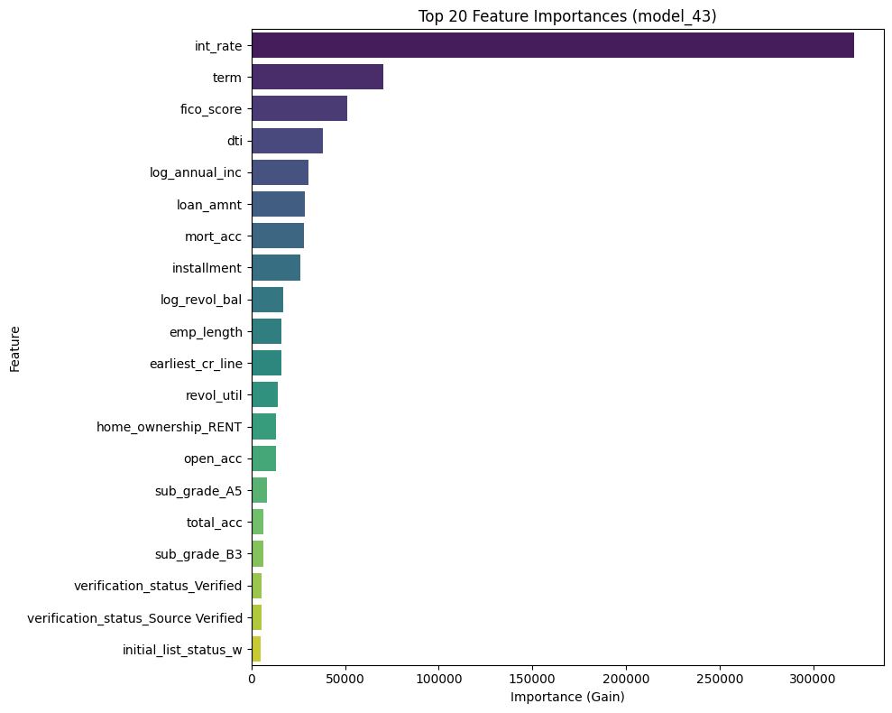

```python
import seaborn as sns

plt.figure(figsize=(10, 8))
sns.barplot(data=feature_importance_df_43.head(20), x='Importance', y='Feature', palette='viridis')
plt.title("Top 20 Feature Importances (model_43)")
plt.xlabel("Importance (Gain)")
plt.ylabel("Feature")
plt.tight_layout()
plt.show()
```